# **Exploring Genomics of Drug Sensitivity in Cancer (GDSC)**

## **Overview:**

> In this project, you will explore a real-world dataset on drug sensitivity in cancer, focusing on how genomic features influence response to treatment. Please note that the goal is not to arrive at a single correct answer, but to investigate patterns in the data, ask meaningful and contextual biological questions, demonstrate various data handling and cleaning techniques and of course, communicate results clearly.

> Try as much as possible to be innovative, creative and use clear graphics to showcase your results clearly.

## **Metadata**

> Columns: Description

> COSMIC_ID: Unique Identifier on COSMIC

> CELL_LINE_NAME: Name of cell line

> TCGA_DESC: TCGA Code for cancer type

> DRUG_ID: Drug ID

> DRUG_NAME: Drug Name

> LN_IC50: Natural logarithm of the IC50

> AUC: Area under the dose dependent curve

> Z_SCORE: Z score of deviations from the mean of zero; the closer to zero, the better

> GDSC Tissue descriptor 1: System description

> GDSC Tissue descriptor 2: Specific organ or tissue

> Cancer Type (matching TCGA label): Same as the TCGA

> Microsatellite instability Status (MSI): MSI-L (Minor instability), MSI-H; High instability, MSS: No instability or repaired mutation

> Screen Medium: Medium for screening

> Growth Properties: Growth properties

> CNA: Is copy number altered?

> Gene Expression: Is gene expressed?

> Methylation: Is gene methylated?

> TARGET: genetic target of drug

> TARGET_PATHWAY: pathway of genetic target

```python
import pandas as pd
!pip install openpyxl
gdsc = pd.read_excel('https://github.com/HackBio-Internship/public_datasets/raw/refs/heads/main/GDSC.xlsx')
```

## **Understanding the dataset**

```python
print(f"Shape of the dataset: {gdsc.shape}")
```

```
Shape of the dataset: (162103, 19)
```

**Comments**

> The dataset contains 162103 rows and 19 columns.

```python
print("\nFirst 5 rows of the dataset:")
display(gdsc.head())
```

```
First 5 rows of the dataset:
```

|  | COSMIC_ID | CELL_LINE_NAME | TCGA_DESC | DRUG_ID | DRUG_NAME | LN_IC50 | AUC | Z_SCORE | GDSC Tissue descriptor 1 | GDSC Tissue descriptor 2 | Cancer Type (matching TCGA label) | Microsatellite instability Status (MSI) | Screen Medium | Growth Properties | CNA | Gene Expression | Methylation | TARGET | TARGET_PATHWAY |
| --- | --- | --- | --- | --- | --- | --- | --- | --- | --- | --- | --- | --- | --- | --- | --- | --- | --- | --- | --- |
| 0 | 683667 | PFSK-1 | MB | 1003 | Camptothecin | -1.463887 | 0.930220 | 0.433123 | nervous_system | medulloblastoma | MB | MSS/MSI-L | R | Adherent | Y | Y | Y | TOP1 | DNA replication |
| 1 | 687448 | COLO-829 | SKCM | 1003 | Camptothecin | -1.235034 | 0.867348 | 0.557727 | skin | melanoma | SKCM | MSS/MSI-L | R | Adherent | Y | Y | Y | TOP1 | DNA replication |
| 2 | 687455 | RT4 | BLCA | 1003 | Camptothecin | -2.963191 | 0.821438 | -0.383200 | urogenital_system | Bladder | BLCA | MSS/MSI-L | D/F12 | Adherent | Y | Y | Y | TOP1 | DNA replication |
| 3 | 687457 | SW780 | BLCA | 1003 | Camptothecin | -1.449138 | 0.905050 | 0.441154 | urogenital_system | Bladder | BLCA | MSS/MSI-L | D/F12 | Adherent | Y | Y | Y | TOP1 | DNA replication |
| 4 | 687459 | TCCSUP | BLCA | 1003 | Camptothecin | -2.350633 | 0.843430 | -0.049682 | urogenital_system | Bladder | BLCA | MSS/MSI-L | D/F12 | Adherent | Y | Y | Y | TOP1 | DNA replication |

```python
print("\nLast 5 rows of the dataset:")
display(gdsc.tail())
```

```
Last 5 rows of the dataset:
```

|  | COSMIC_ID | CELL_LINE_NAME | TCGA_DESC | DRUG_ID | DRUG_NAME | LN_IC50 | AUC | Z_SCORE | GDSC Tissue descriptor 1 | GDSC Tissue descriptor 2 | Cancer Type (matching TCGA label) | Microsatellite instability Status (MSI) | Screen Medium | Growth Properties | CNA | Gene Expression | Methylation | TARGET | TARGET_PATHWAY |
| --- | --- | --- | --- | --- | --- | --- | --- | --- | --- | --- | --- | --- | --- | --- | --- | --- | --- | --- | --- |
| 162098 | 1659818 | MM1S | MM | 2499 | N-acetyl cysteine | 9.316959 | 0.988236 | -0.775041 | myeloma | myeloma | MM | MSS/MSI-L | R | Suspension | Y | Y | Y | Metabolism | Metabolism |
| 162099 | 1659928 | SNU-175 | COREAD | 2499 | N-acetyl cysteine | 10.127082 | 0.976746 | 0.156872 | large_intestine | large_intestine | COAD/READ | MSI-H | R | Suspension | Y | Y | Y | Metabolism | Metabolism |
| 162100 | 1660034 | SNU-407 | COREAD | 2499 | N-acetyl cysteine | 8.576377 | 0.913378 | -1.626959 | large_intestine | large_intestine | COAD/READ | MSI-H | R | Adherent | Y | Y | Y | Metabolism | Metabolism |
| 162101 | 1660035 | SNU-61 | COREAD | 2499 | N-acetyl cysteine | 10.519636 | 0.975001 | 0.608442 | large_intestine | large_intestine | COAD/READ | MSS/MSI-L | R | Adherent | Y | Y | Y | Metabolism | Metabolism |
| 162102 | 1674021 | SNU-C5 | COREAD | 2499 | N-acetyl cysteine | 10.694579 | 0.969969 | 0.809684 | large_intestine | large_intestine | COAD/READ | MSI-H | R | Adherent | Y | Y | Y | Metabolism | Metabolism |

```python
print("\nInformation about the dataset:")
gdsc.info()
```

```
Information about the dataset:
<class 'pandas.core.frame.DataFrame'>
RangeIndex: 162103 entries, 0 to 162102
Data columns (total 19 columns):
 #   Column                                   Non-Null Count   Dtype
---  ------                                   --------------   -----
 0   COSMIC_ID                                162103 non-null  int64
 1   CELL_LINE_NAME                           162103 non-null  object
 2   TCGA_DESC                                162103 non-null  object
 3   DRUG_ID                                  162103 non-null  int64
 4   DRUG_NAME                                162103 non-null  object
 5   LN_IC50                                  162103 non-null  float64
 6   AUC                                      162103 non-null  float64
 7   Z_SCORE                                  162103 non-null  float64
 8   GDSC Tissue descriptor 1                 162103 non-null  object
 9   GDSC Tissue descriptor 2                 162103 non-null  object
 10  Cancer Type (matching TCGA label)        162103 non-null  object
 11  Microsatellite instability Status (MSI)  162103 non-null  object
 12  Screen Medium                            162103 non-null  object
 13  Growth Properties                        162103 non-null  object
 14  CNA                                      162103 non-null  object
 15  Gene Expression                          162103 non-null  object
 16  Methylation                              162103 non-null  object
 17  TARGET                                   162103 non-null  object
 18  TARGET_PATHWAY                           162103 non-null  object
dtypes: float64(3), int64(2), object(14)
memory usage: 23.5+ MB
```

**Comments**

> All columns have 162103 non-null entries, which indicates that there are no missing values across any of the columns.

```python
print("\nMissing values per column:")
display(gdsc.isnull().sum())
```

```
Missing values per column:
```

|  | 0 |
| --- | --- |
| COSMIC_ID | 0 |
| CELL_LINE_NAME | 0 |
| TCGA_DESC | 0 |
| DRUG_ID | 0 |
| DRUG_NAME | 0 |
| LN_IC50 | 0 |
| AUC | 0 |
| Z_SCORE | 0 |
| GDSC Tissue descriptor 1 | 0 |
| GDSC Tissue descriptor 2 | 0 |
| Cancer Type (matching TCGA label) | 0 |
| Microsatellite instability Status (MSI) | 0 |
| Screen Medium | 0 |
| Growth Properties | 0 |
| CNA | 0 |
| Gene Expression | 0 |
| Methylation | 0 |
| TARGET | 0 |
| TARGET_PATHWAY | 0 |

**dtype:** int64

**Comments**

> Further confirmed that there are no missing values in the dataset.

```python
print("\nTransposed Descriptive statistics of the dataset:")
display(gdsc.describe(include='all').T)
```

```
Transposed Descriptive statistics of the dataset:
```

|  | count | unique | top | freq | mean | std | min | 25% | 50% | 75% | max |
| --- | --- | --- | --- | --- | --- | --- | --- | --- | --- | --- | --- |
| COSMIC_ID | 162103.0 | NaN | NaN | NaN | 985763.361344 | 224021.250911 | 683667.0 | 905978.0 | 909257.0 | 1240143.0 | 1674021.0 |
| CELL_LINE_NAME | 162103 | 737 | SW620 | 254 | NaN | NaN | NaN | NaN | NaN | NaN | NaN |
| TCGA_DESC | 162103 | 30 | LUAD | 13300 | NaN | NaN | NaN | NaN | NaN | NaN | NaN |
| DRUG_ID | 162103.0 | NaN | NaN | NaN | 1554.527603 | 406.964712 | 1003.0 | 1086.0 | 1598.0 | 1910.0 | 2499.0 |
| DRUG_NAME | 162103 | 246 | Ulixertinib | 1302 | NaN | NaN | NaN | NaN | NaN | NaN | NaN |
| LN_IC50 | 162103.0 | NaN | NaN | NaN | 2.822644 | 2.836231 | -8.642551 | 1.47617 | 3.271447 | 4.767629 | 13.820189 |
| AUC | 162103.0 | NaN | NaN | NaN | 0.879924 | 0.148592 | 0.006282 | 0.845967 | 0.941467 | 0.973917 | 0.998904 |
| Z_SCORE | 162103.0 | NaN | NaN | NaN | 0.037711 | 0.999098 | -6.909716 | -0.615884 | 0.04893 | 0.686466 | 7.978776 |
| GDSC Tissue descriptor 1 | 162103 | 17 | urogenital_system | 17777 | NaN | NaN | NaN | NaN | NaN | NaN | NaN |
| GDSC Tissue descriptor 2 | 162103 | 33 | lung_NSCLC_adenocarcinoma | 13300 | NaN | NaN | NaN | NaN | NaN | NaN | NaN |
| Cancer Type (matching TCGA label) | 162103 | 30 | LUAD | 13300 | NaN | NaN | NaN | NaN | NaN | NaN | NaN |
| Microsatellite instability Status (MSI) | 162103 | 2 | MSS/MSI-L | 150781 | NaN | NaN | NaN | NaN | NaN | NaN | NaN |
| Screen Medium | 162103 | 2 | R | 83928 | NaN | NaN | NaN | NaN | NaN | NaN | NaN |
| Growth Properties | 162103 | 3 | Adherent | 122381 | NaN | NaN | NaN | NaN | NaN | NaN | NaN |
| CNA | 162103 | 2 | Y | 161445 | NaN | NaN | NaN | NaN | NaN | NaN | NaN |
| Gene Expression | 162103 | 2 | Y | 158342 | NaN | NaN | NaN | NaN | NaN | NaN | NaN |
| Methylation | 162103 | 2 | Y | 158601 | NaN | NaN | NaN | NaN | NaN | NaN | NaN |
| TARGET | 162103 | 183 | PARP1, PARP2 | 3584 | NaN | NaN | NaN | NaN | NaN | NaN | NaN |
| TARGET_PATHWAY | 162103 | 23 | PI3K/MTOR signaling | 17343 | NaN | NaN | NaN | NaN | NaN | NaN | NaN |

### **Visualizing Distributions of Numerical Features**

Let's visualize the distributions of `LN_IC50`, `AUC`, and `Z_SCORE` using histograms to understand their spread, central tendency, and any potential skewness or outliers.

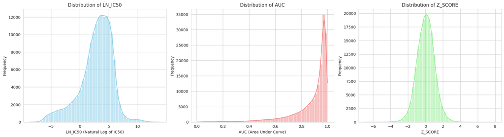

```python
import matplotlib.pyplot as plt
import seaborn as sns

# Set the aesthetic style of the plots
sns.set_style("whitegrid")

plt.figure(figsize=(18, 5))

# Histogram for LN_IC50
plt.subplot(1, 3, 1) # 1 row, 3 columns, 1st plot
sns.histplot(gdsc['LN_IC50'], kde=True, bins=50, color='skyblue')
plt.title('Distribution of LN_IC50')
plt.xlabel('LN_IC50 (Natural Log of IC50)')
plt.ylabel('Frequency')

# Histogram for AUC
plt.subplot(1, 3, 2) # 1 row, 3 columns, 2nd plot
sns.histplot(gdsc['AUC'], kde=True, bins=50, color='lightcoral')
plt.title('Distribution of AUC')
plt.xlabel('AUC (Area Under Curve)')
plt.ylabel('Frequency')

# Histogram for Z_SCORE
plt.subplot(1, 3, 3) # 1 row, 3 columns, 3rd plot
sns.histplot(gdsc['Z_SCORE'], kde=True, bins=50, color='lightgreen')
plt.title('Distribution of Z_SCORE')
plt.xlabel('Z_SCORE')
plt.ylabel('Frequency')

plt.tight_layout()
plt.show()
```

**Comments**

**Distribution of LN_IC50 (Natural Log of IC50):**

> Negative LN_IC50 values indicate extremely potent drugs, as they achieve half-maximal inhibition at very low concentrations. The more negative the LN_IC50, the more potent the drug.

> The tail extending to the right suggests some instances of very high IC50 values, meaning low drug potency.

**Distribution of AUC (Area Under Curve):**

> The AUC histogram is heavily skewed towards higher values (closer to 1) indicating that a significant portion of drug-cell line interactions results in relatively high resistance.

> A high AUC means the drug is less effective over the dose range tested.

> The smaller presence of values closer to 0 indicates cases where the drug is more effective or where the cells are more sensitive to the drug.

**Distribution of Z_SCORE:**

> The Z_SCORE distribution is roughly centered around zero, thus, indicating that a large number of drug-cell line interactions result in responses that are close to the average effectiveness for that particular drug.

> Values far from zero (both positive and negative) represent responses that deviate significantly from the average for that drug.

> Negative Z-scores indicate increased sensitivity, while positive Z-scores indicate increased resistance.

### **Exploring Value Counts for Categorical Features**

Let's examine the unique values and their frequencies for each categorical column to understand the distribution within these features.

```python
import os

for column in gdsc.select_dtypes(include='object').columns:
    print(f"\nValue Counts for '{column}':")
    value_counts = gdsc[column].value_counts()

    # Set a threshold for when to save to CSV vs. display directly
    if len(value_counts) > 500: # For example, if more than 500 unique values
        file_name = f"{column}_value_counts.csv"
        value_counts.to_csv(file_name)
        print(f"  (Full value counts for {column} saved to '{file_name}' due to large number of unique values ({len(value_counts)}). Showing top 10 below:)")
        display(value_counts.head(10))
    else:
        display(value_counts)
    print("--------------------------------------------------")
```

```
Value Counts for 'CELL_LINE_NAME':
  (Full value counts for CELL_LINE_NAME saved to 'CELL_LINE_NAME_value_counts.csv' due to large number of unique values (737). Showing top 10 below:)
```

| CELL_LINE_NAME | count |
| --- | --- |
| SW620 | 254 |
| HT-29 | 254 |
| PC-14 | 254 |
| A375 | 253 |
| C32 | 253 |
| HCC38 | 244 |
| ZR-75-30 | 244 |
| CAL-85-1 | 244 |
| MDA-MB-436 | 244 |
| CAMA-1 | 244 |

**dtype:** int64

```
--------------------------------------------------

Value Counts for 'TCGA_DESC':
```

| TCGA_DESC | count |
| --- | --- |
| LUAD | 13300 |
| SCLC | 11938 |
| BRCA | 11166 |
| SKCM | 10661 |
| COREAD | 10531 |
| ESCA | 7919 |
| HNSC | 7738 |
| GBM | 7403 |
| OV | 7237 |
| DLBC | 7003 |
| KIRC | 6758 |
| NB | 6660 |
| ALL | 5879 |
| PAAD | 5875 |
| LAML | 5154 |
| STAD | 4240 |
| MM | 3787 |
| BLCA | 3675 |
| LIHC | 3342 |
| LUSC | 3295 |
| THCA | 3293 |
| CESC | 3285 |
| LGG | 3163 |
| LCML | 2246 |
| UCEC | 2147 |
| PRAD | 1433 |
| MESO | 1355 |
| MB | 912 |
| CLL | 469 |
| ACC | 239 |

**dtype:** int64

```
--------------------------------------------------

Value Counts for 'DRUG_NAME':
```

| DRUG_NAME | count |
| --- | --- |
| Ulixertinib | 1302 |
| Oxaliplatin | 1287 |
| Fulvestrant | 1283 |
| Selumetinib | 1273 |
| Dactinomycin | 1264 |
| ... | ... |
| SL0101 | 159 |
| Tretinoin | 159 |
| BX795 | 159 |
| CHIR-99021 | 159 |
| IOX2 | 159 |

246 rows × 1 columns

**dtype:** int64

```
--------------------------------------------------

Value Counts for 'GDSC Tissue descriptor 1':
```

| GDSC Tissue descriptor 1 | count |
| --- | --- |
| urogenital_system | 17777 |
| lung_NSCLC | 16595 |
| aero_dig_tract | 15657 |
| leukemia | 13124 |
| lung_SCLC | 11938 |
| nervous_system | 11478 |
| breast | 11166 |
| skin | 10661 |
| large_intestine | 10531 |
| lymphoma | 7627 |
| digestive_system | 7582 |
| kidney | 6997 |
| neuroblastoma | 6660 |
| pancreas | 5875 |
| myeloma | 3787 |
| thyroid | 3293 |
| lung | 1355 |

**dtype:** int64

```
--------------------------------------------------

Value Counts for 'GDSC Tissue descriptor 2':
```

| GDSC Tissue descriptor 2 | count |
| --- | --- |
| lung_NSCLC_adenocarcinoma | 13300 |
| lung_small_cell_carcinoma | 11938 |
| breast | 11166 |
| melanoma | 10661 |
| glioma | 10566 |
| large_intestine | 10531 |
| oesophagus | 7919 |
| head and neck | 7738 |
| ovary | 7237 |
| B_cell_lymphoma | 7003 |
| kidney | 6758 |
| neuroblastoma | 6660 |
| pancreas | 5875 |
| acute_myeloid_leukaemia | 4918 |
| stomach | 4240 |
| Bladder | 3675 |
| liver | 3342 |
| lung_NSCLC_squamous_cell_carcinoma | 3295 |
| thyroid | 3293 |
| cervix | 3285 |
| myeloma | 2845 |
| lymphoblastic_leukemia | 2619 |
| chronic_myeloid_leukaemia | 2246 |
| endometrium | 2147 |
| lymphoblastic_T_cell_leukaemia | 1976 |
| prostate | 1433 |
| mesothelioma | 1355 |
| medulloblastoma | 912 |
| lymphoid_neoplasm other | 862 |
| T_cell_leukemia | 713 |
| haematopoietic_neoplasm other | 704 |
| leukemia | 652 |
| adrenal_gland | 239 |

**dtype:** int64

```
--------------------------------------------------

Value Counts for 'Cancer Type (matching TCGA label)':
```

| Cancer Type (matching TCGA label) | count |
| --- | --- |
| LUAD | 13300 |
| SCLC | 11938 |
| BRCA | 11166 |
| SKCM | 10661 |
| COAD/READ | 10531 |
| ESCA | 7919 |
| HNSC | 7738 |
| GBM | 7403 |
| OV | 7237 |
| DLBC | 7003 |
| KIRC | 6758 |
| NB | 6660 |
| ALL | 5879 |
| PAAD | 5875 |
| LAML | 5154 |
| STAD | 4240 |
| MM | 3787 |
| BLCA | 3675 |
| LIHC | 3342 |
| LUSC | 3295 |
| THCA | 3293 |
| CESC | 3285 |
| LGG | 3163 |
| LCML | 2246 |
| UCEC | 2147 |
| PRAD | 1433 |
| MESO | 1355 |
| MB | 912 |
| CLL | 469 |
| ACC | 239 |

**dtype:** int64

```
--------------------------------------------------

Value Counts for 'Microsatellite instability Status (MSI)':
```

| Microsatellite instability Status (MSI) | count |
| --- | --- |
| MSS/MSI-L | 150781 |
| MSI-H | 11322 |

**dtype:** int64

```
--------------------------------------------------

Value Counts for 'Screen Medium':
```

| Screen Medium | count |
| --- | --- |
| R | 83928 |
| D/F12 | 78175 |

**dtype:** int64

```
--------------------------------------------------

Value Counts for 'Growth Properties':
```

| Growth Properties | count |
| --- | --- |
| Adherent | 122381 |
| Suspension | 34884 |
| Semi-Adherent | 4838 |

**dtype:** int64

```
--------------------------------------------------

Value Counts for 'CNA':
```

| CNA | count |
| --- | --- |
| Y | 161445 |
| N | 658 |

**dtype:** int64

```
--------------------------------------------------

Value Counts for 'Gene Expression':
```

| Gene Expression | count |
| --- | --- |
| Y | 158342 |
| N | 3761 |

**dtype:** int64

```
--------------------------------------------------

Value Counts for 'Methylation':
```

| Methylation | count |
| --- | --- |
| Y | 158601 |
| N | 3502 |

**dtype:** int64

```
--------------------------------------------------

Value Counts for 'TARGET':
```

| TARGET | count |
| --- | --- |
| PARP1, PARP2 | 3584 |
| MEK1, MEK2 | 3464 |
| TOP1 | 3300 |
| EGFR | 2914 |
| TNKS1, TNKS2 | 2810 |
| ... | ... |
| TBK1, PDK1 (PDPK1), IKK, AURKB, AURKC | 159 |
| RSK, AURKB, PIM1, PIM3 | 159 |
| AR | 159 |
| Induces reactive oxygen species | 159 |
| EGLN1 | 159 |

183 rows × 1 columns

**dtype:** int64

```
--------------------------------------------------

Value Counts for 'TARGET_PATHWAY':
```

| TARGET_PATHWAY | count |
| --- | --- |
| PI3K/MTOR signaling | 17343 |
| Other | 15237 |
| Other, kinases | 13149 |
| DNA replication | 12400 |
| ERK MAPK signaling | 10176 |
| Genome integrity | 9284 |
| Cell cycle | 8845 |
| Chromatin histone methylation | 8152 |
| RTK signaling | 8037 |
| Apoptosis regulation | 7693 |
| Chromatin histone acetylation | 6233 |
| Chromatin other | 5981 |
| WNT signaling | 5784 |
| Protein stability and degradation | 5362 |
| EGFR signaling | 5119 |
| Mitosis | 4914 |
| IGF1R signaling | 4195 |
| Metabolism | 3667 |
| Hormone-related | 2896 |
| p53 pathway | 2873 |
| Cytoskeleton | 2592 |
| JNK and p38 signaling | 1446 |
| ABL signaling | 725 |

**dtype:** int64

### **Correlation Analysis of Numerical Features**

Let's examine the correlation matrix for the numerical features (`LN_IC50`, `AUC`, `Z_SCORE`, `COSMIC_ID`, `DRUG_ID`) to understand the relationships between them. A correlation matrix helps to identify how strongly and in what direction two variables are related.

```python
# Select only numerical columns for correlation calculation
numerical_cols = gdsc.select_dtypes(include=['number'])

# Calculate the correlation matrix
correlation_matrix = numerical_cols.corr()

# Display the correlation matrix
print("Correlation Matrix of Numerical Features:")
display(correlation_matrix)
```

```
Correlation Matrix of Numerical Features:
```

|  | COSMIC_ID | DRUG_ID | LN_IC50 | AUC | Z_SCORE |
| --- | --- | --- | --- | --- | --- |
| COSMIC_ID | 1.000000 | -0.005969 | -0.019769 | -0.011371 | -0.038508 |
| DRUG_ID | -0.005969 | 1.000000 | 0.172981 | 0.049615 | -0.000016 |
| LN_IC50 | -0.019769 | 0.172981 | 1.000000 | 0.760447 | 0.501577 |
| AUC | -0.011371 | 0.049615 | 0.760447 | 1.000000 | 0.443160 |
| Z_SCORE | -0.038508 | -0.000016 | 0.501577 | 0.443160 | 1.000000 |

**Comments on Correlation Matrix**

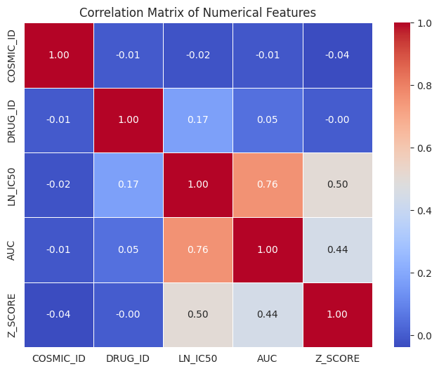

```python
import matplotlib.pyplot as plt
import seaborn as sns

# Set up the matplotlib figure
plt.figure(figsize=(8, 6))

# Draw the heatmap with the mask and correct aspect ratio
sns.heatmap(correlation_matrix, annot=True, cmap='coolwarm', fmt=".2f", linewidths=.5)
plt.title('Correlation Matrix of Numerical Features')
plt.show()
```

**Comments**

> In essence, the heatmap confirms that LN_IC50, AUC, and Z_SCORE are all related and generally move in the same direction when indicating drug sensitivity or resistance, with LN_IC50 and AUC showing the strongest interdependence.

### **Pairplot of Numerical Features**

Let's generate a pairplot to visualize the pairwise relationships and distributions of `LN_IC50`, `AUC`, and `Z_SCORE`. This helps in understanding correlations, identifying patterns, and detecting outliers.

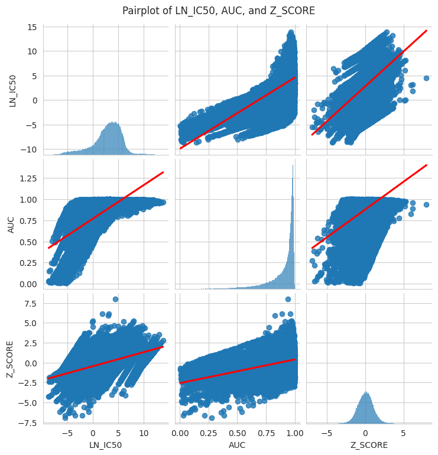

```python
import seaborn as sns
import matplotlib.pyplot as plt

# Select the relevant numerical columns for the pairplot
relevant_cols = ['LN_IC50', 'AUC', 'Z_SCORE']

# Create the pairplot
fig = sns.pairplot(gdsc[relevant_cols], kind='reg', plot_kws={'line_kws':{'color':'red'}})
fig.fig.suptitle('Pairplot of LN_IC50, AUC, and Z_SCORE', y=1.02) # Add a title to the figure
plt.show()
```

**Comments**

The pairplot visually confirms and elaborates on the relationships between LN_IC50, AUC, and Z_SCORE.

**Diagonal Plots (Histograms):** These display the distribution of each variable individually.

> AUC: Heavily skewed towards higher values, suggesting a prevalence of less effective drug interactions.

> Z_SCORE: Centered around zero, with values deviating in both positive (resistance) and negative (sensitivity) directions.

**Off-Diagonal Plots (Scatter Plots with Regression Lines):** These plots show the pairwise relationships between the variables:

> LN_IC50 vs. AUC: The scatter plot and the red regression line clearly show a strong positive linear relationship. As LN_IC50 increases (less sensitive), AUC also tends to increase (less effective), which is expected.

Overall, the pairplot provides a clear visual representation of the strong positive correlations previously identified in the correlation matrix, highlighting that these three metrics move together in indicating drug sensitivity or resistance.

### **Scatter Plot: LN_IC50 vs. AUC for All Drugs**

Let's visualize the relationship between `LN_IC50` and `AUC` across all drugs using a scatter plot. This plot will help us understand the distribution and the confirmed strong positive correlation between these two key drug effectiveness metrics more broadly.

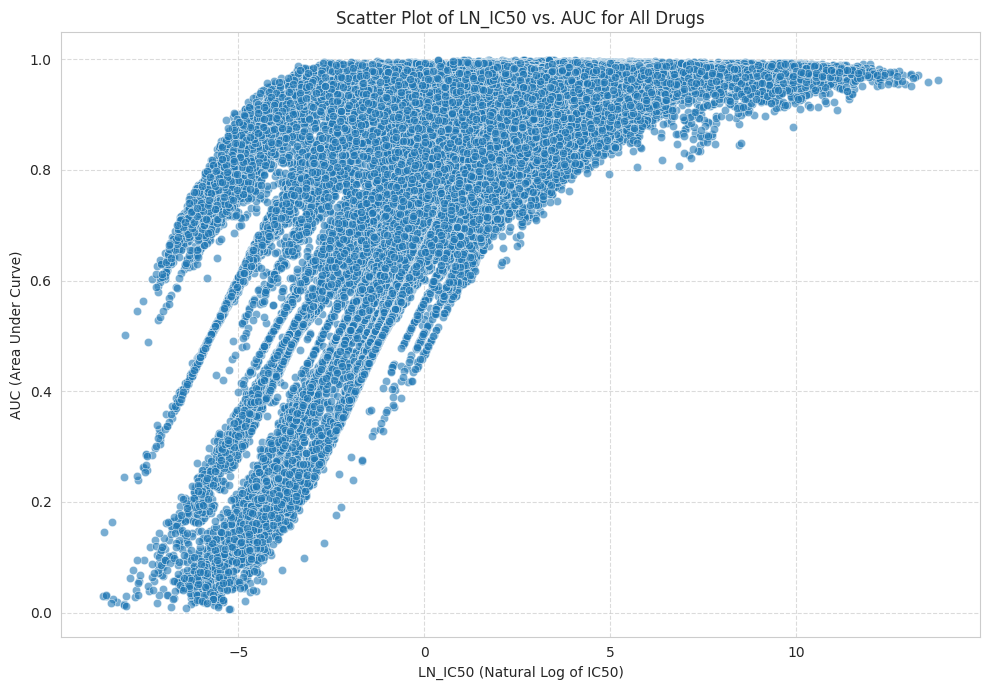

```python
import matplotlib.pyplot as plt
import seaborn as sns

sns.set_style("whitegrid")

plt.figure(figsize=(10, 7))
sns.scatterplot(x='LN_IC50', y='AUC', data=gdsc, alpha=0.6)
plt.title('Scatter Plot of LN_IC50 vs. AUC for All Drugs')
plt.xlabel('LN_IC50 (Natural Log of IC50)')
plt.ylabel('AUC (Area Under Curve)')
plt.grid(True, linestyle='--', alpha=0.7)
plt.tight_layout()
plt.show()
```

**Comments**

> The scatter plot visually confirms the strong positive correlation between LN_IC50 and AUC that we observed in the correlation matrix and the pairplot.

> As LN_IC50 increases (indicating lower potency), AUC also tends to increase (indicating lower overall effectiveness).

> The spread of the points illustrates the variability in this relationship across different drug-cell line combinations, but the general upward trend is evident.

> This plot provides a concise and intuitive way to understand how these two key drug effectiveness metrics move together.

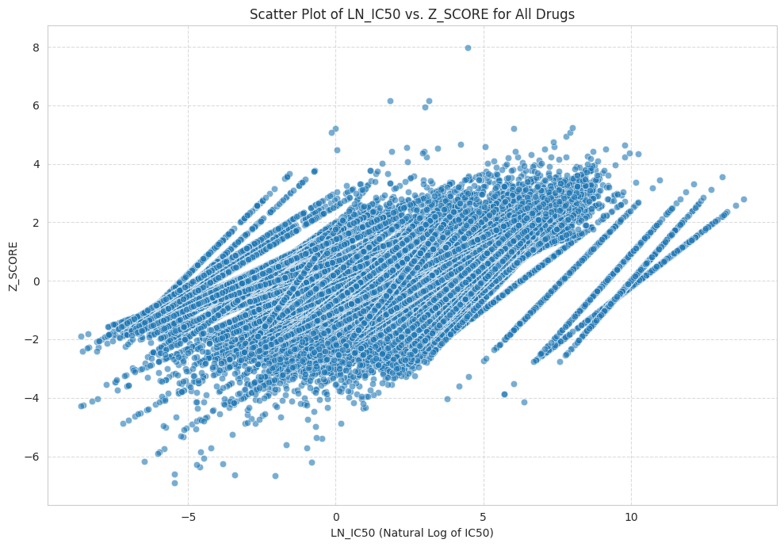

```python
import matplotlib.pyplot as plt
import seaborn as sns

sns.set_style("whitegrid")

plt.figure(figsize=(10, 7))
sns.scatterplot(x='LN_IC50', y='Z_SCORE', data=gdsc, alpha=0.6)
plt.title('Scatter Plot of LN_IC50 vs. Z_SCORE for All Drugs')
plt.xlabel('LN_IC50 (Natural Log of IC50)')
plt.ylabel('Z_SCORE')
plt.grid(True, linestyle='--', alpha=0.7)
plt.tight_layout()
plt.show()
```

**Comments**

> As LN_IC50 increases (indicating lower potency), Z_SCORE also tends to increase (indicating higher resistance).

> This confirms that both metrics are generally in agreement regarding drug effectiveness across the dataset.

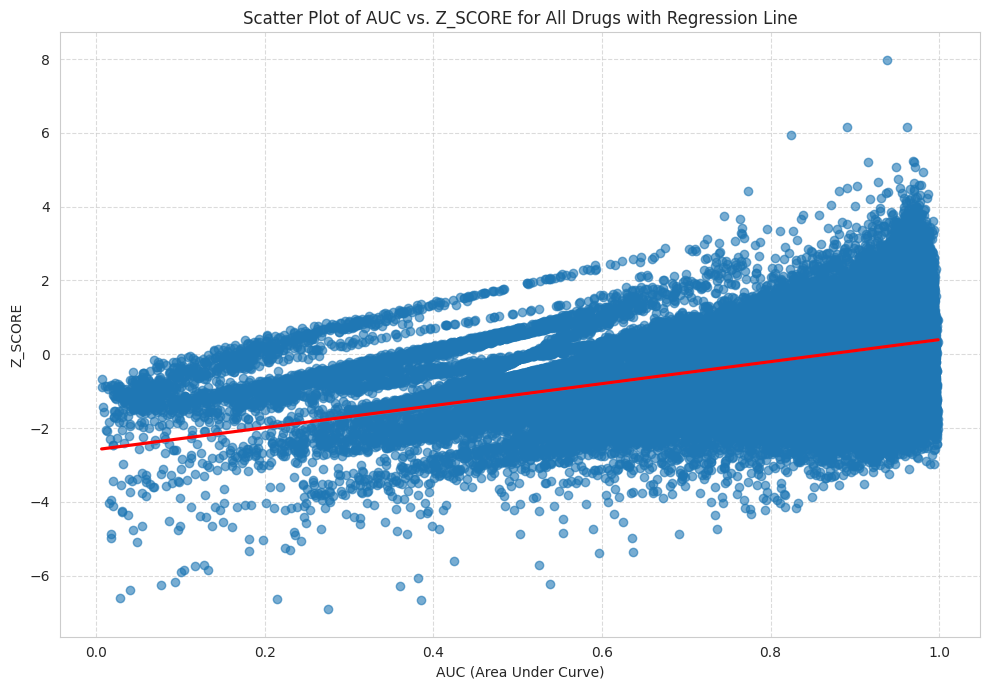

```python
import matplotlib.pyplot as plt
import seaborn as sns

sns.set_style("whitegrid")

plt.figure(figsize=(10, 7))
sns.regplot(x='AUC', y='Z_SCORE', data=gdsc, scatter_kws={'alpha':0.6}, line_kws={'color':'red'})
plt.title('Scatter Plot of AUC vs. Z_SCORE for All Drugs with Regression Line')
plt.xlabel('AUC (Area Under Curve)')
plt.ylabel('Z_SCORE')
plt.grid(True, linestyle='--', alpha=0.7)
plt.tight_layout()
plt.show()
```

**Comments**

> The upward sloping red regression line indicates that as AUC increases (drugs become less effective), the Z_SCORE also tends to increase (indicating higher resistance).

> This reinforces the understanding that both metrics are consistent indicators of drug effectiveness.

## **Drug Sensitivity patterns**

### **Identifying Most Effective Drugs**

To determine which drugs appear to be most effective, we will analyze the average values of `LN_IC50`, `AUC`, and `Z_SCORE` for each drug. Lower `LN_IC50` and `AUC` values, and more negative `Z_SCORE` values, indicate greater drug effectiveness.

```python
import numpy as np

# Group by DRUG_NAME and calculate the mean for the sensitivity metrics
drug_effectiveness = gdsc.groupby('DRUG_NAME')[['LN_IC50', 'AUC', 'Z_SCORE']].mean().reset_index()

print("Top 10 Drugs by Lowest Average LN_IC50 (most potent):")
display(drug_effectiveness.sort_values(by='LN_IC50').head(10))

print("\nTop 10 Drugs by Lowest Average AUC (most effective):")
display(drug_effectiveness.sort_values(by='AUC').head(10))

print("\nTop 10 Drugs by Most Negative Average Z_SCORE (highest sensitivity):")
display(drug_effectiveness.sort_values(by='Z_SCORE').head(10))
```

```
Top 10 Drugs by Lowest Average LN_IC50 (most potent):
```

|  | DRUG_NAME | LN_IC50 | AUC | Z_SCORE |
| --- | --- | --- | --- | --- |
| 185 | Romidepsin | -5.177964 | 0.803534 | 0.060958 |
| 45 | Bortezomib | -4.746884 | 0.779567 | -0.008408 |
| 200 | Sepantronium bromide | -4.056148 | 0.205525 | 0.063142 |
| 65 | Dactinomycin | -3.670432 | 0.627695 | 0.062702 |
| 195 | SN-38 | -3.359790 | 0.769116 | 0.032973 |
| 231 | Vinblastine | -3.353560 | 0.718984 | 0.063531 |
| 70 | Docetaxel | -3.327287 | 0.706232 | 0.039840 |
| 67 | Daporinad | -3.322740 | 0.638247 | 0.022480 |
| 173 | Paclitaxel | -3.005582 | 0.874649 | 0.050876 |
| 77 | Eg5_9814 | -2.886607 | 0.777225 | 0.025662 |

```
Top 10 Drugs by Lowest Average AUC (most effective):
```

|  | DRUG_NAME | LN_IC50 | AUC | Z_SCORE |
| --- | --- | --- | --- | --- |
| 200 | Sepantronium bromide | -4.056148 | 0.205525 | 0.063142 |
| 203 | Staurosporine | -2.753419 | 0.406821 | 0.028684 |
| 51 | CDK9_5038 | -2.017681 | 0.517699 | 0.058003 |
| 136 | MG-132 | -1.288915 | 0.526065 | -0.007645 |
| 69 | Dinaciclib | -2.609900 | 0.582044 | 0.028122 |
| 196 | Sabutoclax | -0.263076 | 0.595061 | 0.065111 |
| 52 | CDK9_5576 | -0.132813 | 0.600394 | 0.037025 |
| 65 | Dactinomycin | -3.670432 | 0.627695 | 0.062702 |
| 67 | Daporinad | -3.322740 | 0.638247 | 0.022480 |
| 105 | Gemcitabine | -0.631929 | 0.659869 | 0.044488 |

```
Top 10 Drugs by Most Negative Average Z_SCORE (highest sensitivity):
```

|  | DRUG_NAME | LN_IC50 | AUC | Z_SCORE |
| --- | --- | --- | --- | --- |
| 183 | Refametinib | 2.127847 | 0.812440 | -0.076374 |
| 165 | PD0325901 | 1.206118 | 0.867602 | -0.063512 |
| 199 | Selumetinib | 3.459949 | 0.892482 | -0.062325 |
| 218 | Trametinib | 0.089114 | 0.818366 | -0.056452 |
| 21 | AZD6482 | 3.316181 | 0.907171 | -0.055349 |
| 191 | SCH772984 | 2.371954 | 0.873866 | -0.045804 |
| 197 | Sapitinib | 3.636424 | 0.917213 | -0.042888 |
| 76 | ERK_6604 | 3.245353 | 0.891326 | -0.028366 |
| 228 | VX-11e | 2.671350 | 0.864831 | -0.027217 |
| 75 | ERK_2440 | 2.523962 | 0.848196 | -0.025504 |

These tables show the drugs that consistently rank high in effectiveness based on the different sensitivity metrics. Drugs appearing in the top ranks across all three metrics are likely the most broadly effective.

### **Visualizing Top 10 Most Potent Drugs by LN_IC50**

Let's visualize the top 10 drugs with the lowest average `LN_IC50` values, indicating they are the most potent. A bar plot will effectively highlight these drugs and their relative potencies.

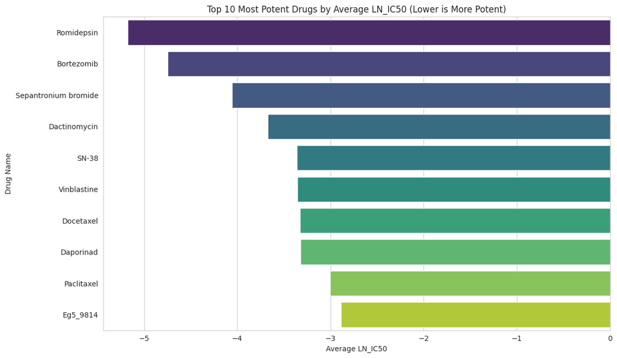

```python
import matplotlib.pyplot as plt
import seaborn as sns

sns.set_style("whitegrid")

# Get the top 10 drugs by lowest average LN_IC50 (most potent)
most_potent_drugs = drug_effectiveness.sort_values(by='LN_IC50', ascending=True).head(10)

plt.figure(figsize=(12, 7))
sns.barplot(x='LN_IC50', y='DRUG_NAME', data=most_potent_drugs, hue='DRUG_NAME', palette='viridis', legend=False)
plt.title('Top 10 Most Potent Drugs by Average LN_IC50 (Lower is More Potent)')
plt.xlabel('Average LN_IC50')
plt.ylabel('Drug Name')
plt.tight_layout()
plt.show()
```

**Comments**

> The most potent drug (with the lowest average LN_IC50) is Romidepsin.

> Among these top 10 drugs, the least potent drug (with the highest average LN_IC50 in this selection) is Eg5_9814.

### **Visualizing AUC Scores for Top 10 Most Potent Drugs**

Let's compare the `AUC` scores for the same top 10 drugs identified as most potent by `LN_IC50`. A lower `AUC` value indicates greater overall effectiveness.

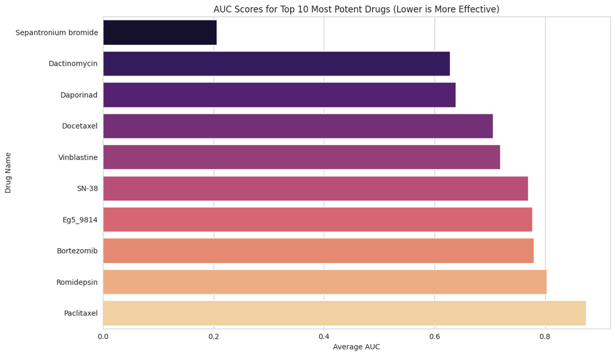

```python
import matplotlib.pyplot as plt
import seaborn as sns

sns.set_style("whitegrid")

# Sort the most potent drugs by AUC (lower is better) for this specific plot
most_potent_drugs_by_auc = most_potent_drugs.sort_values(by='AUC', ascending=True)

plt.figure(figsize=(12, 7))
sns.barplot(x='AUC', y='DRUG_NAME', data=most_potent_drugs_by_auc, hue='DRUG_NAME', palette='magma', legend=False)
plt.title('AUC Scores for Top 10 Most Potent Drugs (Lower is More Effective)')
plt.xlabel('Average AUC')
plt.ylabel('Drug Name')
plt.tight_layout()
plt.show()
```

**Comments**

> Among these highly potent drugs, 'Sepantronium bromide' stands out with a significantly lower average AUC, indicating it is not only potent but also highly effective overall.

> Other drugs like 'Dactinomycin' and 'Daporinad' also show relatively good AUC scores, suggesting good overall effectiveness, although higher than Sepantronium bromide.

> This visualization helps to further refine our understanding of these drugs' performance by considering another key metric.

### **Visualizing Top 10 Most Potent Drugs by Z_SCORE**

Let's visualize the top 10 drugs with the most negative average `Z_SCORE` values, indicating they are the most sensitive/potent. A bar plot will effectively highlight these drugs and their relative Z_SCOREs.

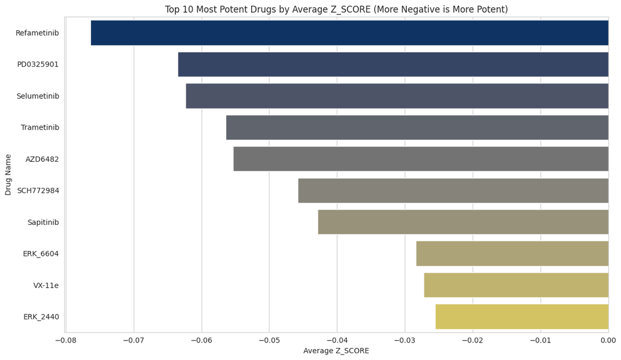

```python
import matplotlib.pyplot as plt
import seaborn as sns

sns.set_style("whitegrid")

# Get the top 10 drugs by most negative average Z_SCORE (highest sensitivity)
most_sensitive_drugs = drug_effectiveness.sort_values(by='Z_SCORE', ascending=True).head(10)

plt.figure(figsize=(12, 7))
sns.barplot(x='Z_SCORE', y='DRUG_NAME', data=most_sensitive_drugs, hue='DRUG_NAME', palette='cividis', legend=False)
plt.title('Top 10 Most Potent Drugs by Average Z_SCORE (More Negative is More Potent)')
plt.xlabel('Average Z_SCORE')
plt.ylabel('Drug Name')
plt.tight_layout()
plt.show()
```

**Comments**

> This plot visually identifies the drugs that induce the highest sensitivity (most negative Z_SCORE) in cell lines.

> By comparing this to the LN_IC50 and AUC plots, we can see if there is consistency across all three metrics for identifying the most potent drugs.

### **Identifying Overlapping Effective Drugs**

To find drugs that are consistently effective across all three metrics (`LN_IC50`, `AUC`, and `Z_SCORE`), we'll identify the drugs that appear in the top 10 for each of these metrics and then find their intersection.

```python
# Get the top 10 drugs for each metric
top_10_ln_ic50 = set(drug_effectiveness.sort_values(by='LN_IC50').head(10)['DRUG_NAME'])
top_10_auc = set(drug_effectiveness.sort_values(by='AUC').head(10)['DRUG_NAME'])
top_10_z_score = set(drug_effectiveness.sort_values(by='Z_SCORE').head(10)['DRUG_NAME'])

# Find the intersection of these sets
overlapping_effective_drugs = top_10_ln_ic50.intersection(top_10_auc, top_10_z_score)

print("Drugs appearing in the top 10 across all three effectiveness metrics:")
if overlapping_effective_drugs:
    for drug in overlapping_effective_drugs:
        print(f"- {drug}")
else:
    print("No drugs found that are in the top 10 for all three metrics.")
```

```
Drugs appearing in the top 10 across all three effectiveness metrics:
No drugs found that are in the top 10 for all three metrics.
```

### **Identifying Drugs Effective Across At Least Two Metrics**

Since no drug appeared in the top 10 for all three metrics, let's broaden our search to identify drugs that are consistently effective across at least two of the three metrics: `LN_IC50`, `AUC`, and `Z_SCORE`. This will help highlight drugs with broader effectiveness profiles.

```python
import collections

# Calculate intersections for each pair of metrics
overlap_ln_ic50_auc = top_10_ln_ic50.intersection(top_10_auc)
overlap_ln_ic50_z_score = top_10_ln_ic50.intersection(top_10_z_score)
overlap_auc_z_score = top_10_auc.intersection(top_10_z_score)

# Combine all drugs that appear in at least two metrics using a union
drugs_in_at_least_two_metrics = overlap_ln_ic50_auc.union(overlap_ln_ic50_z_score, overlap_auc_z_score)

print("Drugs appearing in the top 10 for at least two effectiveness metrics:")
if drugs_in_at_least_two_metrics:
    # Create a dictionary to store which metrics each drug is in the top 10 for
    drug_metric_breakdown = collections.defaultdict(list)
    for drug in drugs_in_at_least_two_metrics:
        if drug in top_10_ln_ic50:
            drug_metric_breakdown[drug].append('LN_IC50')
        if drug in top_10_auc:
            drug_metric_breakdown[drug].append('AUC')
        if drug in top_10_z_score:
            drug_metric_breakdown[drug].append('Z_SCORE')

    # Print the drugs along with their corresponding metrics
    for drug in sorted(drug_metric_breakdown.keys()):
        metrics = ', '.join(drug_metric_breakdown[drug])
        print(f"- {drug} ({metrics})")
else:
    print("No drugs found that are in the top 10 for at least two metrics.")
```

```
Drugs appearing in the top 10 for at least two effectiveness metrics:
- Dactinomycin (LN_IC50, AUC)
- Daporinad (LN_IC50, AUC)
- Sepantronium bromide (LN_IC50, AUC)
```

**Comments**

> Based on the analysis, the following drugs appear in the top 10 for at least two (LN_IC50, and AUC)of the three effectiveness metrics:
1. Dactinomycin
2. Daporinad
3. Sepantronium bromide

> This indicates that these three drugs consistently demonstrate high potency (low LN_IC50) and overall effectiveness (low AUC) across various cell lines, making them strong candidates for further investigation as broadly effective agents.

### **Visualizing Effectiveness of Top Drugs**

To further understand the effectiveness profiles of 'Dactinomycin', 'Daporinad', and 'Sepantronium bromide', we will visualize their distributions across `LN_IC50`, `AUC`, and `Z_SCORE`. This will help us compare their spread and central tendency for each metric.

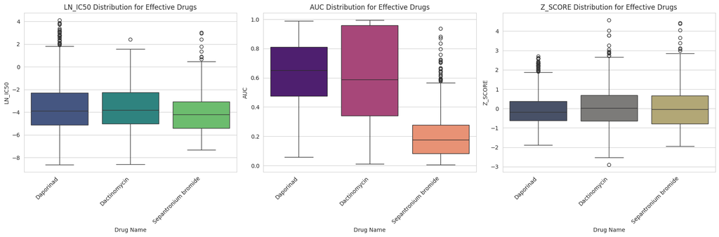

```python
import matplotlib.pyplot as plt
import seaborn as sns

# Filter the original DataFrame for the identified effective drugs
effective_drugs_list = ['Dactinomycin', 'Daporinad', 'Sepantronium bromide']
df_effective = gdsc[gdsc['DRUG_NAME'].isin(effective_drugs_list)]

sns.set_style("whitegrid")

plt.figure(figsize=(18, 6))

# Box plot for LN_IC50
plt.subplot(1, 3, 1)
sns.boxplot(x='DRUG_NAME', y='LN_IC50', data=df_effective, hue='DRUG_NAME', palette='viridis', legend=False)
plt.title('LN_IC50 Distribution for Effective Drugs')
plt.xlabel('Drug Name')
plt.ylabel('LN_IC50')
plt.xticks(rotation=45, ha='right')

# Box plot for AUC
plt.subplot(1, 3, 2)
sns.boxplot(x='DRUG_NAME', y='AUC', data=df_effective, hue='DRUG_NAME', palette='magma', legend=False)
plt.title('AUC Distribution for Effective Drugs')
plt.xlabel('Drug Name')
plt.ylabel('AUC')
plt.xticks(rotation=45, ha='right')

# Box plot for Z_SCORE
plt.subplot(1, 3, 3)
sns.boxplot(x='DRUG_NAME', y='Z_SCORE', data=df_effective, hue='DRUG_NAME', palette='cividis', legend=False)
plt.title('Z_SCORE Distribution for Effective Drugs')
plt.xlabel('Drug Name')
plt.ylabel('Z_SCORE')
plt.xticks(rotation=45, ha='right')

plt.tight_layout()
plt.show()
```

These box plots illustrate the distribution of LN_IC50, AUC, and Z_SCORE for each of the three identified drugs.

- **LN_IC50 Distribution:** Lower values indicate higher potency. Sepantronium bromide shows a distribution with generally lower (more negative) LN_IC50 values, suggesting it is highly potent.
- **AUC Distribution:** Lower values indicate greater overall effectiveness. Sepantronium bromide again stands out with its AUC distribution heavily skewed towards lower values, reinforcing its strong effectiveness.
- **Z_SCORE Distribution:** More negative values indicate higher sensitivity. Sepantronium bromide's Z_SCORE distribution is centered around slightly positive values, indicating a mixed response but still appearing in the top metrics due to its strong performance in AUC and LN_IC50.

### **Statistical Significance Test: ANOVA and Post-Hoc Analysis**

To formally compare the effectiveness of 'Dactinomycin', 'Daporinad', and 'Sepantronium bromide', we will use a One-Way Analysis of Variance (ANOVA). ANOVA tests if there are significant differences between the means of three or more independent groups. If the ANOVA test yields a significant p-value (typically p < 0.05), it indicates that at least one drug's effectiveness is significantly different from another's.

Following a significant ANOVA result, we will perform a Tukey's Honestly Significant Difference (HSD) post-hoc test. This test allows us to make pairwise comparisons between the drug groups while controlling for the family-wise error rate, determining exactly which pairs of drugs have statistically significant differences in their effectiveness metrics.

```python
import scipy.stats as stats
from statsmodels.stats.multicomp import pairwise_tukeyhsd
import pandas as pd

# Filter the original DataFrame for the identified effective drugs
effective_drugs_list = ['Dactinomycin', 'Daporinad', 'Sepantronium bromide']
df_effective = gdsc[gdsc['DRUG_NAME'].isin(effective_drugs_list)].copy()

metrics = ['LN_IC50', 'AUC', 'Z_SCORE']

for metric in metrics:
    print(f"\n--- ANOVA for {metric} ---")
    # Perform one-way ANOVA
    f_statistic, p_value = stats.f_oneway(
        df_effective[df_effective['DRUG_NAME'] == 'Dactinomycin'][metric],
        df_effective[df_effective['DRUG_NAME'] == 'Daporinad'][metric],
        df_effective[df_effective['DRUG_NAME'] == 'Sepantronium bromide'][metric]
    )

    print(f"F-statistic: {f_statistic:.3f}")
    print(f"P-value: {p_value:.3f}")

    if p_value < 0.05:
        print(f"Significant difference found for {metric} (p < 0.05). Performing Tukey's HSD post-hoc test.")

        # Perform Tukey's HSD post-hoc test
        tukey_result = pairwise_tukeyhsd(
            endog=df_effective[metric],
            groups=df_effective['DRUG_NAME'],
            alpha=0.05
        )
        print(tukey_result)
    else:
        print(f"No significant difference found for {metric} (p >= 0.05).")
```

```
--- ANOVA for LN_IC50 ---
F-statistic: 19.577
P-value: 0.000
Significant difference found for LN_IC50 (p < 0.05). Performing Tukey's HSD post-hoc test.
          Multiple Comparison of Means - Tukey HSD, FWER=0.05
========================================================================
   group1           group2        meandiff p-adj   lower   upper  reject
------------------------------------------------------------------------
Dactinomycin            Daporinad   0.3477 0.0045  0.0901  0.6053   True
Dactinomycin Sepantronium bromide  -0.3857 0.0001 -0.6032 -0.1682   True
   Daporinad Sepantronium bromide  -0.7334    0.0 -1.0147 -0.4521   True
------------------------------------------------------------------------

--- ANOVA for AUC ---
F-statistic: 677.300
P-value: 0.000
Significant difference found for AUC (p < 0.05). Performing Tukey's HSD post-hoc test.
          Multiple Comparison of Means - Tukey HSD, FWER=0.05
========================================================================
   group1           group2        meandiff p-adj   lower   upper  reject
------------------------------------------------------------------------
Dactinomycin            Daporinad   0.0106 0.7433 -0.0232  0.0443  False
Dactinomycin Sepantronium bromide  -0.4222    0.0 -0.4506 -0.3937   True
   Daporinad Sepantronium bromide  -0.4327    0.0 -0.4695 -0.3959   True
------------------------------------------------------------------------

--- ANOVA for Z_SCORE ---
F-statistic: 0.298
P-value: 0.742
No significant difference found for Z_SCORE (p >= 0.05).
```

#### **Interpretation of Statistical Tests**

**ANOVA Results:**

- For each metric (`LN_IC50`, `AUC`, `Z_SCORE`), if the **P-value is less than 0.05**, we reject the null hypothesis, meaning there is a statistically significant difference in the average effectiveness of at least one pair of drugs.
- If the **P-value is greater than or equal to 0.05**, we do not have sufficient evidence to claim a significant difference in average effectiveness among the drugs for that metric.

**Tukey's HSD Post-Hoc Test (if ANOVA is significant):**

- The Tukey's HSD table shows pairwise comparisons between the drug names.
- Look at the `p-adj` (adjusted p-value) column for each comparison:
  - If `p-adj` is **less than 0.05**, the difference between that pair of drugs is considered statistically significant.
  - If `p-adj` is **greater than or equal to 0.05**, there is no statistically significant difference between that pair of drugs.
- The `meandiff` column indicates the difference in means between the two groups being compared. **A positive value means the mean of the 'group2' is higher than 'group1', and a negative value means it's lower.**
- `lower` and `upper` provide the confidence interval for the mean difference.

**Comments**

> **For LN_IC50 (Potency):** All three drugs are significantly different from each other in terms of potency. 'Sepantronium bromide' is the most potent, followed by 'Dactinomycin', and then 'Daporinad'.

> **For AUC (Overall Effectiveness):** Conclusion for AUC: 'Sepantronium bromide' is significantly more effective overall than both 'Dactinomycin' and 'Daporinad'. However, 'Dactinomycin' and 'Daporinad' do not show a statistically significant difference in their overall effectiveness.

> **For Z_SCORE (Sensitivity):** ANOVA Result: The P-value is 0.742, which is greater than 0.05. This means there is no statistically significant difference in the average Z_SCORE among 'Dactinomycin', 'Daporinad', and 'Sepantronium bromide'. Their average sensitivities are statistically similar.

**Overall Summary:**

> 'Sepantronium bromide' stands out as having significantly higher potency (LN_IC50) and greater overall effectiveness (AUC) compared to both 'Dactinomycin' and 'Daporinad'.

> While 'Dactinomycin' is more potent than 'Daporinad', their overall effectiveness (AUC) is similar.

> For general sensitivity (Z_SCORE), there's no statistically significant difference identified among these three drugs.

### **Identifying Least Effective Drugs Overall**

To identify the drug with the least effectiveness across the entire dataset, we will analyze drugs with the highest average `LN_IC50`, highest average `AUC`, and highest average `Z_SCORE`.

**Visualizing Top 10 Least Potent Drugs by LN_IC50**

Let's visualize the top 10 drugs with the highest average `LN_IC50` values, indicating they are the least potent. A bar plot will effectively highlight these drugs and their relative potencies.

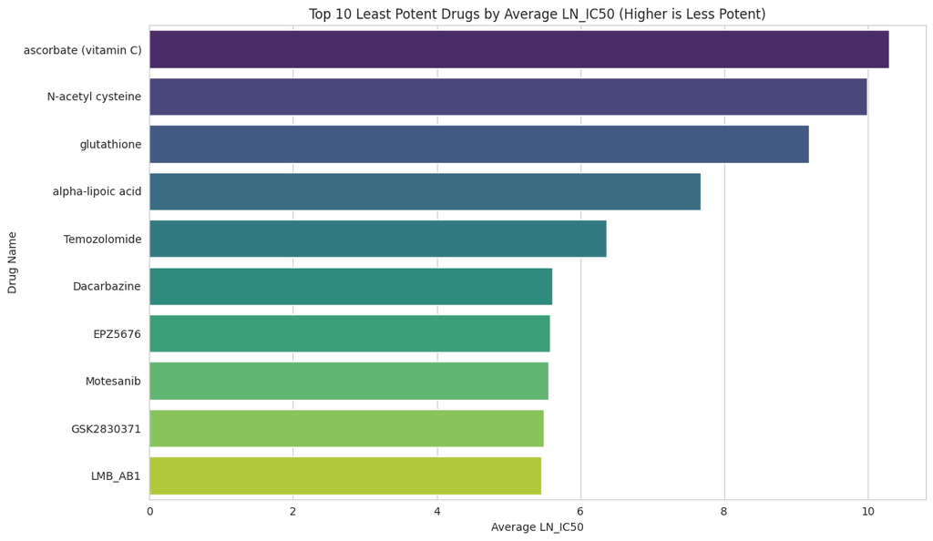

```python
import matplotlib.pyplot as plt
import seaborn as sns

sns.set_style("whitegrid")

# Get the top 10 drugs by highest average LN_IC50 (least potent)
least_potent_drugs = drug_effectiveness.sort_values(by='LN_IC50', ascending=False).head(10)

plt.figure(figsize=(12, 7))
sns.barplot(x='LN_IC50', y='DRUG_NAME', data=least_potent_drugs, hue='DRUG_NAME', palette='viridis', legend=False)
plt.title('Top 10 Least Potent Drugs by Average LN_IC50 (Higher is Less Potent)')
plt.xlabel('Average LN_IC50')
plt.ylabel('Drug Name')
plt.tight_layout()
plt.show()
```

### **Visualizing Top 10 Least Effective Drugs by AUC**

Let's visualize the top 10 drugs with the highest average `AUC` values, indicating they are the least effective overall. A bar plot will effectively highlight these drugs and their relative effectiveness.

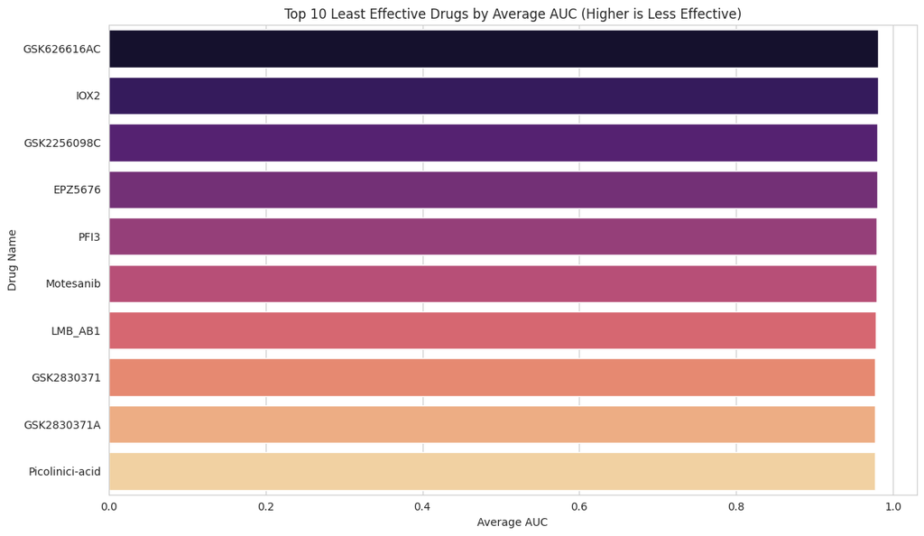

```python
import matplotlib.pyplot as plt
import seaborn as sns

sns.set_style("whitegrid")

# Get the top 10 drugs by highest average AUC (least effective overall)
least_effective_drugs = drug_effectiveness.sort_values(by='AUC', ascending=False).head(10)

plt.figure(figsize=(12, 7))
sns.barplot(x='AUC', y='DRUG_NAME', data=least_effective_drugs, hue='DRUG_NAME', palette='magma', legend=False)
plt.title('Top 10 Least Effective Drugs by Average AUC (Higher is Less Effective)')
plt.xlabel('Average AUC')
plt.ylabel('Drug Name')
plt.tight_layout()
plt.show()
```

### **Visualizing Top 10 Least Sensitive Drugs by Z_SCORE**

Let's visualize the top 10 drugs with the highest average `Z_SCORE` values, indicating they are the least sensitive (or most resistant) overall. A bar plot will effectively highlight these drugs and their relative sensitivity.

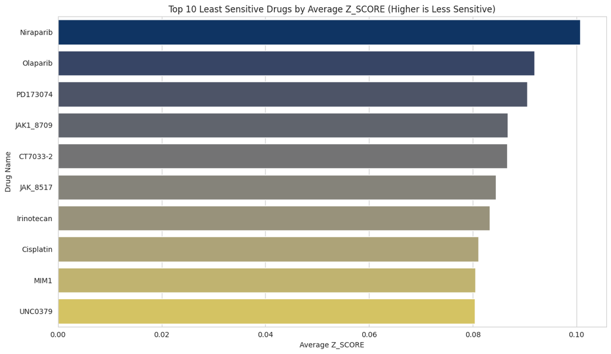

```python
import matplotlib.pyplot as plt
import seaborn as sns

sns.set_style("whitegrid")

# Get the top 10 drugs by highest average Z_SCORE (least sensitive/most resistant)
least_sensitive_drugs = drug_effectiveness.sort_values(by='Z_SCORE', ascending=False).head(10)

plt.figure(figsize=(12, 7))
sns.barplot(x='Z_SCORE', y='DRUG_NAME', data=least_sensitive_drugs, hue='DRUG_NAME', palette='cividis', legend=False)
plt.title('Top 10 Least Sensitive Drugs by Average Z_SCORE (Higher is Less Sensitive)')
plt.xlabel('Average Z_SCORE')
plt.ylabel('Drug Name')
plt.tight_layout()
plt.show()
```

### **Identifying the Top 10 Drugs that are Considered Least Effective Overall**

```python
# Find the top 10 drugs by Highest Average LN_IC50 (least potent)
print("Top 10 Drugs by Highest Average LN_IC50 (least potent):")
display(drug_effectiveness.sort_values(by='LN_IC50', ascending=False).head(10))

# Find the top 10 drugs by Highest Average AUC (least effective overall)
print("\nTop 10 Drugs by Highest Average AUC (least effective overall):")
display(drug_effectiveness.sort_values(by='AUC', ascending=False).head(10))

# Find the top 10 drugs by Highest Average Z_SCORE (lowest sensitivity/highest resistance)
print("\nTop 10 Drugs by Highest Average Z_SCORE (lowest sensitivity/highest resistance):")
display(drug_effectiveness.sort_values(by='Z_SCORE', ascending=False).head(10))
```

```
Top 10 Drugs by Highest Average LN_IC50 (least potent):
```

|  | DRUG_NAME | LN_IC50 | AUC | Z_SCORE |
| --- | --- | --- | --- | --- |
| 244 | ascorbate (vitamin C) | 10.291935 | 0.963827 | 0.032547 |
| 148 | N-acetyl cysteine | 9.988227 | 0.962348 | -0.002857 |
| 245 | glutathione | 9.181100 | 0.969636 | 0.017659 |
| 243 | alpha-lipoic acid | 7.672468 | 0.972786 | 0.023510 |
| 214 | Temozolomide | 6.358420 | 0.972075 | 0.077305 |
| 64 | Dacarbazine | 5.611383 | 0.968497 | 0.018174 |
| 74 | EPZ5676 | 5.579809 | 0.980019 | 0.045079 |
| 147 | Motesanib | 5.555627 | 0.978912 | 0.075317 |
| 97 | GSK2830371 | 5.488680 | 0.977324 | 0.065695 |
| 126 | LMB_AB1 | 5.460292 | 0.978679 | 0.065686 |

```
Top 10 Drugs by Highest Average AUC (least effective overall):
```

|  | DRUG_NAME | LN_IC50 | AUC | Z_SCORE |
| --- | --- | --- | --- | --- |
| 102 | GSK626616AC | 1.025521 | 0.981654 | 0.073915 |
| 111 | IOX2 | 2.372007 | 0.981285 | 0.040874 |
| 92 | GSK2256098C | 4.353509 | 0.980234 | 0.070989 |
| 74 | EPZ5676 | 5.579809 | 0.980019 | 0.045079 |
| 169 | PFI3 | 5.437599 | 0.979452 | 0.058899 |
| 147 | Motesanib | 5.555627 | 0.978912 | 0.075317 |
| 126 | LMB_AB1 | 5.460292 | 0.978679 | 0.065686 |
| 97 | GSK2830371 | 5.488680 | 0.977324 | 0.065695 |
| 98 | GSK2830371A | 5.223824 | 0.977283 | 0.048355 |
| 176 | Picolinici-acid | 5.294191 | 0.977247 | 0.041048 |

```
Top 10 Drugs by Highest Average Z_SCORE (lowest sensitivity/highest resistance):
```

|  | DRUG_NAME | LN_IC50 | AUC | Z_SCORE |
| --- | --- | --- | --- | --- |
| 153 | Niraparib | 4.263269 | 0.942962 | 0.100720 |
| 159 | Olaparib | 4.345971 | 0.950341 | 0.091920 |
| 166 | PD173074 | 3.885804 | 0.941337 | 0.090486 |
| 117 | JAK1_8709 | 4.196605 | 0.945221 | 0.086762 |
| 55 | CT7033-2 | 1.566400 | 0.781718 | 0.086648 |
| 118 | JAK_8517 | 3.151402 | 0.884886 | 0.084461 |
| 116 | Irinotecan | 2.641372 | 0.866661 | 0.083251 |
| 59 | Cisplatin | 3.371854 | 0.923898 | 0.081099 |
| 137 | MIM1 | 4.045276 | 0.939558 | 0.080486 |
| 221 | UNC0379 | 3.615968 | 0.915422 | 0.080379 |

**Comments**

> Considering the top 10 drugs for each 'least effective' metric, no drug consistently appears in all three categories (highest average LN_IC50, highest average AUC, and highest average Z_SCORE).

> Thus, different drugs exhibit their 'least effectiveness' based on the specific metric being considered.

### **Identifying Overlapping Least Effective Drugs**

```python
# Get the top 10 drugs for each metric
top_10_highest_ln_ic50 = set(drug_effectiveness.sort_values(by='LN_IC50', ascending=False).head(10)['DRUG_NAME'])
top_10_highest_auc = set(drug_effectiveness.sort_values(by='AUC', ascending=False).head(10)['DRUG_NAME'])
top_10_highest_z_score = set(drug_effectiveness.sort_values(by='Z_SCORE', ascending=False).head(10)['DRUG_NAME'])

# Find the intersection of these sets
overlapping_least_effective_drugs = top_10_highest_ln_ic50.intersection(top_10_highest_auc, top_10_highest_z_score)

print("Drugs appearing in the top 10 across all three 'least effective' metrics:")
if overlapping_least_effective_drugs:
    for drug in overlapping_least_effective_drugs:
        print(f"- {drug}")
else:
    print("No drugs found that are in the top 10 for all three 'least effective' metrics.")
```

```
Drugs appearing in the top 10 across all three 'least effective' metrics:
No drugs found that are in the top 10 for all three 'least effective' metrics.
```

### **Identifying Drugs Least Effective Across At Least Two Metrics**

Since no drug appeared in the top 10 for all three 'least effective' metrics, let's broaden our search to identify drugs that are consistently least effective across at least two of the three metrics: `LN_IC50`, `AUC`, and `Z_SCORE`. This will help highlight drugs with broader ineffectiveness profiles.

```python
import collections

# Calculate intersections for each pair of metrics
overlap_highest_ln_ic50_auc = top_10_highest_ln_ic50.intersection(top_10_highest_auc)
overlap_highest_ln_ic50_z_score = top_10_highest_ln_ic50.intersection(top_10_highest_z_score)
overlap_highest_auc_z_score = top_10_highest_auc.intersection(top_10_highest_z_score)

# Combine all drugs that appear in at least two metrics using a union
drugs_in_at_least_two_least_effective_metrics = overlap_highest_ln_ic50_auc.union(overlap_highest_ln_ic50_z_score, overlap_highest_auc_z_score)

print("Drugs appearing in the top 10 for at least two 'least effective' metrics:")
if drugs_in_at_least_two_least_effective_metrics:
    # Create a dictionary to store which metrics each drug is in the top 10 for
    drug_metric_breakdown_least = collections.defaultdict(list)
    for drug in drugs_in_at_least_two_least_effective_metrics:
        if drug in top_10_highest_ln_ic50:
            drug_metric_breakdown_least[drug].append('Highest_LN_IC50')
        if drug in top_10_highest_auc:
            drug_metric_breakdown_least[drug].append('Highest_AUC')
        if drug in top_10_highest_z_score:
            drug_metric_breakdown_least[drug].append('Highest_Z_SCORE')

    # Print the drugs along with their corresponding metrics
    for drug in sorted(drug_metric_breakdown_least.keys()):
        metrics = ', '.join(drug_metric_breakdown_least[drug])
        print(f"- {drug} ({metrics})")
else:
    print("No drugs found that are in the top 10 for at least two 'least effective' metrics.")
```

```
Drugs appearing in the top 10 for at least two 'least effective' metrics:
- EPZ5676 (Highest_LN_IC50, Highest_AUC)
- GSK2830371 (Highest_LN_IC50, Highest_AUC)
- LMB_AB1 (Highest_LN_IC50, Highest_AUC)
- Motesanib (Highest_LN_IC50, Highest_AUC)
```

**Comments**

> The four drugs are consistently among the least effective, indicating that they have high IC50 values (low potency) and high AUC values (poor overall effectiveness).

> This suggests that these drugs are generally less effective across the cell lines studied, based on these two important metrics.

### **Identifying the Single Least Effective Drug Overall**

Among the drugs consistently identified as least effective across multiple metrics, let's pinpoint the single drug that is *least effective overall*. We will do this by comparing their average `AUC` values, where a higher `AUC` indicates lower overall effectiveness.

```python
least_effective_overlap_drugs = ['EPZ5676', 'GSK2830371', 'LMB_AB1', 'Motesanib']

# Filter the drug_effectiveness DataFrame for these drugs
overall_least_effective_drugs_df = drug_effectiveness[drug_effectiveness['DRUG_NAME'].isin(least_effective_overlap_drugs)]

# Sort by AUC in descending order to find the least effective overall
overall_least_effective_drugs_df = overall_least_effective_drugs_df.sort_values(by='AUC', ascending=False)

print("Overall Least Effective Drugs (ranked by AUC):")
display(overall_least_effective_drugs_df)
```

```
Overall Least Effective Drugs (ranked by AUC):
```

|  | DRUG_NAME | LN_IC50 | AUC | Z_SCORE |
| --- | --- | --- | --- | --- |
| 74 | EPZ5676 | 5.579809 | 0.980019 | 0.045079 |
| 147 | Motesanib | 5.555627 | 0.978912 | 0.075317 |
| 126 | LMB_AB1 | 5.460292 | 0.978679 | 0.065686 |
| 97 | GSK2830371 | 5.488680 | 0.977324 | 0.065695 |

**Comments**

> Based on the average AUC values, EPZ5676 is identified as the single least effective drug among the four, with the highest AUC value of 0.980019.

> It is followed by Motesanib, LMB_AB1, and GSK2830371.

### **Identifying Drugs with Highly Variable Responses**

To identify drugs that show highly variable responses across different cell lines, we will calculate the standard deviation of `LN_IC50`, `AUC`, and `Z_SCORE` for each drug. A higher standard deviation indicates greater variability in response.

```python
# Group by DRUG_NAME and calculate the standard deviation for the sensitivity metrics
drug_variability = gdsc.groupby('DRUG_NAME')[['LN_IC50', 'AUC', 'Z_SCORE']].std().reset_index()

print("Top 10 Drugs by Highest Standard Deviation of LN_IC50 (most variable potency):")
display(drug_variability.sort_values(by='LN_IC50', ascending=False).head(10))

print("\nTop 10 Drugs by Highest Standard Deviation of AUC (most variable effectiveness):")
display(drug_variability.sort_values(by='AUC', ascending=False).head(10))

print("\nTop 10 Drugs by Highest Standard Deviation of Z_SCORE (most variable sensitivity):")
display(drug_variability.sort_values(by='Z_SCORE', ascending=False).head(10))
```

```
Top 10 Drugs by Highest Standard Deviation of LN_IC50 (most variable potency):
```

|  | DRUG_NAME | LN_IC50 | AUC | Z_SCORE |
| --- | --- | --- | --- | --- |
| 105 | Gemcitabine | 2.941950 | 0.234819 | 0.977581 |
| 20 | AZD5991 | 2.759418 | 0.186487 | 0.986386 |
| 67 | Daporinad | 2.735583 | 0.223516 | 0.987256 |
| 70 | Docetaxel | 2.546911 | 0.258092 | 0.992675 |
| 36 | BI-2536 | 2.459347 | 0.198379 | 1.010322 |
| 68 | Dasatinib | 2.394058 | 0.172630 | 1.031775 |
| 144 | Methotrexate | 2.389344 | 0.172257 | 0.960298 |
| 217 | Tozasertib | 2.386865 | 0.185867 | 1.002931 |
| 19 | AZD5582 | 2.345364 | 0.186384 | 1.004422 |
| 218 | Trametinib | 2.301612 | 0.194131 | 1.020231 |

```
Top 10 Drugs by Highest Standard Deviation of AUC (most variable effectiveness):
```

|  | DRUG_NAME | LN_IC50 | AUC | Z_SCORE |
| --- | --- | --- | --- | --- |
| 65 | Dactinomycin | 1.860500 | 0.315533 | 0.991142 |
| 195 | SN-38 | 1.933588 | 0.263135 | 0.953998 |
| 70 | Docetaxel | 2.546911 | 0.258092 | 0.992675 |
| 105 | Gemcitabine | 2.941950 | 0.234819 | 0.977581 |
| 67 | Daporinad | 2.735583 | 0.223516 | 0.987256 |
| 51 | CDK9_5038 | 1.940858 | 0.201548 | 1.006713 |
| 36 | BI-2536 | 2.459347 | 0.198379 | 1.010322 |
| 218 | Trametinib | 2.301612 | 0.194131 | 1.020231 |
| 128 | LMP744 | 2.279247 | 0.191312 | 0.978920 |
| 28 | Alisertib | 2.267331 | 0.187232 | 0.991223 |

```
Top 10 Drugs by Highest Standard Deviation of Z_SCORE (most variable sensitivity):
```

|  | DRUG_NAME | LN_IC50 | AUC | Z_SCORE |
| --- | --- | --- | --- | --- |
| 46 | Bosutinib | 1.597128 | 0.088471 | 1.045139 |
| 26 | Afatinib | 1.523329 | 0.120106 | 1.038790 |
| 189 | SB505124 | 1.576166 | 0.073126 | 1.038549 |
| 243 | alpha-lipoic acid | 1.002309 | 0.016634 | 1.037650 |
| 235 | WEHI-539 | 1.777534 | 0.118783 | 1.036918 |
| 155 | OF-1 | 1.208928 | 0.043207 | 1.036505 |
| 160 | Osimertinib | 1.321848 | 0.068677 | 1.035487 |
| 115 | Ipatasertib | 1.503115 | 0.088412 | 1.034462 |
| 17 | AZD5363 | 1.488519 | 0.098497 | 1.033524 |
| 63 | Dabrafenib | 1.909821 | 0.123146 | 1.032732 |

**Comments**

These tables highlight drugs for which the response metrics (`LN_IC50`, `AUC`, `Z_SCORE`) vary significantly across different cell lines. This high variability suggests that these drugs might be very effective in some cancer contexts but much less so in others, indicating a need for careful selection based on specific cell line or cancer type characteristics.

### **Identifying Overlapping Highly Variable Drugs**

To find drugs that are consistently highly variable across all three metrics (`LN_IC50`, `AUC`, and `Z_SCORE`), we'll identify the drugs that appear in the top 10 for the highest standard deviation of each of these metrics and then find their intersection.

```python
# Get the top 10 drugs for each metric by highest standard deviation
top_10_sd_ln_ic50 = set(drug_variability.sort_values(by='LN_IC50', ascending=False).head(10)['DRUG_NAME'])
top_10_sd_auc = set(drug_variability.sort_values(by='AUC', ascending=False).head(10)['DRUG_NAME'])
top_10_sd_z_score = set(drug_variability.sort_values(by='Z_SCORE', ascending=False).head(10)['DRUG_NAME'])

# Find the intersection of these sets
overlapping_highly_variable_drugs_all = top_10_sd_ln_ic50.intersection(top_10_sd_auc, top_10_sd_z_score)

print("Drugs appearing in the top 10 for highest standard deviation across all three variability metrics:")
if overlapping_highly_variable_drugs_all:
    for drug in overlapping_highly_variable_drugs_all:
        print(f"- {drug}")
else:
    print("No drugs found that are in the top 10 for highest standard deviation across all three metrics.")
```

```
Drugs appearing in the top 10 for highest standard deviation across all three variability metrics:
No drugs found that are in the top 10 for highest standard deviation across all three metrics.
```

### **Identifying Drugs Highly Variable Across At Least Two Metrics**

Since no drug appeared in the top 10 for all three variability metrics, let's broaden our search to identify drugs that are consistently highly variable across at least two of the three metrics: `LN_IC50`, `AUC`, and `Z_SCORE`. This will help highlight drugs with broader variability profiles.

```python
import collections

# Calculate intersections for each pair of metrics
overlap_sd_ln_ic50_auc = top_10_sd_ln_ic50.intersection(top_10_sd_auc)
overlap_sd_ln_ic50_z_score = top_10_sd_ln_ic50.intersection(top_10_sd_z_score)
overlap_sd_auc_z_score = top_10_sd_auc.intersection(top_10_sd_z_score)

# Combine all drugs that appear in at least two metrics using a union
drugs_in_at_least_two_variable_metrics = overlap_sd_ln_ic50_auc.union(overlap_sd_ln_ic50_z_score, overlap_sd_auc_z_score)

print("Drugs appearing in the top 10 for highest standard deviation across at least two variability metrics:")
if drugs_in_at_least_two_variable_metrics:
    # Create a dictionary to store which metrics each drug is in the top 10 for
    drug_metric_breakdown_variable = collections.defaultdict(list)
    for drug in drugs_in_at_least_two_variable_metrics:
        if drug in top_10_sd_ln_ic50:
            drug_metric_breakdown_variable[drug].append('Highest_SD_LN_IC50')
        if drug in top_10_sd_auc:
            drug_metric_breakdown_variable[drug].append('Highest_SD_AUC')
        if drug in top_10_sd_z_score:
            drug_metric_breakdown_variable[drug].append('Highest_SD_Z_SCORE')

    # Print the drugs along with their corresponding metrics
    for drug in sorted(drug_metric_breakdown_variable.keys()):
        metrics = ', '.join(drug_metric_breakdown_variable[drug])
        print(f"- {drug} ({metrics})")
else:
    print("No drugs found that are in the top 10 for highest standard deviation across at least two metrics.")
```

```
Drugs appearing in the top 10 for highest standard deviation across at least two variability metrics:
- BI-2536 (Highest_SD_LN_IC50, Highest_SD_AUC)
- Daporinad (Highest_SD_LN_IC50, Highest_SD_AUC)
- Docetaxel (Highest_SD_LN_IC50, Highest_SD_AUC)
- Gemcitabine (Highest_SD_LN_IC50, Highest_SD_AUC)
- Trametinib (Highest_SD_LN_IC50, Highest_SD_AUC)
```

### **Identifying the Single Most Variable Drug Overall**

Among the drugs consistently identified as highly variable across multiple metrics, let's pinpoint the single drug that is *most variable overall*. We will do this by comparing a combined score of their average standard deviations for `LN_IC50` and `AUC`.

```python
highly_variable_overlap_drugs = ['BI-2536', 'Daporinad', 'Docetaxel', 'Gemcitabine', 'Trametinib']

# Filter the drug_variability DataFrame for these drugs
overall_most_variable_drugs_df = drug_variability[drug_variability['DRUG_NAME'].isin(highly_variable_overlap_drugs)].copy()

# Calculate a combined variability score (e.g., sum of std for LN_IC50 and AUC)
# Since they were identified based on these two metrics, summing them makes sense.
overall_most_variable_drugs_df['Combined_Variability_Score'] = \
    overall_most_variable_drugs_df['LN_IC50'] + overall_most_variable_drugs_df['AUC']

# Sort by Combined_Variability_Score in descending order to find the most variable overall
overall_most_variable_drugs_df = overall_most_variable_drugs_df.sort_values(by='Combined_Variability_Score', ascending=False)

print("Overall Most Variable Drugs (ranked by Combined Variability Score - LN_IC50 + AUC):")
display(overall_most_variable_drugs_df)
```

```
Overall Most Variable Drugs (ranked by Combined Variability Score - LN_IC50 + AUC):
```

|  | DRUG_NAME | LN_IC50 | AUC | Z_SCORE | Combined_Variability_Score |
| --- | --- | --- | --- | --- | --- |
| 105 | Gemcitabine | 2.941950 | 0.234819 | 0.977581 | 3.176768 |
| 67 | Daporinad | 2.735583 | 0.223516 | 0.987256 | 2.959099 |
| 70 | Docetaxel | 2.546911 | 0.258092 | 0.992675 | 2.805003 |
| 36 | BI-2536 | 2.459347 | 0.198379 | 1.010322 | 2.657726 |
| 218 | Trametinib | 2.301612 | 0.194131 | 1.020231 | 2.495743 |

**Comments**

> The table above identifies the overall most variable drug among the selected five, based on a combined score of their standard deviations for LN_IC50 and AUC.

> The drug with the highest 'Combined_Variability_Score' is considered the most variable, indicating the broadest range of responses across different cell lines for these two key metrics.

> This means that **Gemcitabine** exhibits the broadest range of responses across different cell lines concerning its potency (LN_IC50) and overall effectiveness (AUC).

> This high variability suggests that its effectiveness can differ significantly depending on the specific cellular context.

## **Cancer Cell Line Analysis**

### **Identifying Best Performing Drugs Per Cancer Type**

To identify drugs that perform best in specific cancer types, we will analyze the `cancer_type_drug_effectiveness` DataFrame. For each cancer type (`TCGA_DESC`), we will find the drug that exhibits the lowest average `LN_IC50`, lowest average `AUC`, and most negative average `Z_SCORE`.

```python
cancer_type_drug_effectiveness = gdsc.groupby(['TCGA_DESC', 'DRUG_NAME'])[['LN_IC50', 'AUC', 'Z_SCORE']].mean().reset_index()

# Find the drug with the lowest LN_IC50 for each cancer type (most potent)
best_ln_ic50_per_cancer = cancer_type_drug_effectiveness.loc[cancer_type_drug_effectiveness.groupby('TCGA_DESC')['LN_IC50'].idxmin()]
print("Best Drug (by Lowest LN_IC50) per Cancer Type:")
display(best_ln_ic50_per_cancer.sort_values(by='TCGA_DESC'))

# Find the drug with the lowest AUC for each cancer type (most effective overall)
best_auc_per_cancer = cancer_type_drug_effectiveness.loc[cancer_type_drug_effectiveness.groupby('TCGA_DESC')['AUC'].idxmin()]
print("\nBest Drug (by Lowest AUC) per Cancer Type:")
display(best_auc_per_cancer.sort_values(by='TCGA_DESC'))

# Find the drug with the most negative Z_SCORE for each cancer type (highest sensitivity)
best_z_score_per_cancer = cancer_type_drug_effectiveness.loc[cancer_type_drug_effectiveness.groupby('TCGA_DESC')['Z_SCORE'].idxmin()]
print("\nBest Drug (by Most Negative Z_SCORE) per Cancer Type:")
display(best_z_score_per_cancer.sort_values(by='TCGA_DESC'))
```

```
Best Drug (by Lowest LN_IC50) per Cancer Type:
```

|  | TCGA_DESC | DRUG_NAME | LN_IC50 | AUC | Z_SCORE |
| --- | --- | --- | --- | --- | --- |
| 188 | ACC | Sepantronium bromide | -6.290728 | 0.036050 | -1.314318 |
| 299 | ALL | Daporinad | -6.527248 | 0.354709 | -1.134009 |
| 520 | BLCA | Bortezomib | -4.879267 | 0.777569 | -0.132422 |
| 895 | BRCA | Romidepsin | -5.061178 | 0.817601 | 0.177383 |
| 1141 | CESC | Romidepsin | -5.187728 | 0.812315 | 0.051224 |
| 1385 | CLL | SN-38 | -6.780262 | 0.658226 | -1.654627 |
| 1619 | COREAD | Romidepsin | -4.615155 | 0.833148 | 0.622025 |
| 1865 | DLBC | Romidepsin | -5.806695 | 0.786419 | -0.565826 |
| 2111 | ESCA | Romidepsin | -5.258306 | 0.797198 | -0.019135 |
| 2357 | GBM | Romidepsin | -5.287579 | 0.786272 | -0.048318 |
| 2603 | HNSC | Romidepsin | -5.664512 | 0.767822 | -0.424084 |
| 2709 | KIRC | Bortezomib | -4.951412 | 0.754562 | -0.200007 |
| 3141 | LAML | Vinblastine | -5.692262 | 0.506633 | -1.011160 |
| 3219 | LCML | Dasatinib | -6.574776 | 0.158089 | -3.387622 |
| 3573 | LGG | Romidepsin | -5.497415 | 0.780492 | -0.257504 |
| 3809 | LIHC | Romidepsin | -4.509628 | 0.830259 | 0.727226 |
| 4051 | LUAD | Romidepsin | -5.011465 | 0.795522 | 0.226941 |
| 4287 | LUSC | Romidepsin | -5.147758 | 0.798578 | 0.091070 |
| 4406 | MB | Daporinad | -6.421042 | 0.410873 | -1.095680 |
| 4751 | MESO | Romidepsin | -5.004830 | 0.804102 | 0.233556 |
| 4853 | MM | Bortezomib | -5.565737 | 0.733231 | -0.775497 |
| 5121 | NB | Daporinad | -5.187666 | 0.433436 | -0.650561 |
| 5500 | OV | Sepantronium bromide | -4.837564 | 0.162412 | -0.418545 |
| 5731 | PAAD | Romidepsin | -4.273714 | 0.844032 | 0.962410 |
| 5967 | PRAD | Romidepsin | -5.250411 | 0.789231 | -0.011264 |
| 6209 | SCLC | Romidepsin | -5.499425 | 0.788904 | -0.259508 |
| 6455 | SKCM | Romidepsin | -5.707287 | 0.762069 | -0.466727 |
| 6701 | STAD | Romidepsin | -5.576377 | 0.763824 | -0.336221 |
| 6947 | THCA | Romidepsin | -5.483827 | 0.766547 | -0.243958 |
| 7070 | UCEC | Daporinad | -5.600786 | 0.519559 | -0.799654 |

```
Best Drug (by Lowest AUC) per Cancer Type:
```

|  | TCGA_DESC | DRUG_NAME | LN_IC50 | AUC | Z_SCORE |
| --- | --- | --- | --- | --- | --- |
| 188 | ACC | Sepantronium bromide | -6.290728 | 0.036050 | -1.314318 |
| 432 | ALL | Sepantronium bromide | -3.836043 | 0.190993 | 0.198822 |
| 666 | BLCA | Sepantronium bromide | -4.324969 | 0.176841 | -0.102566 |
| 910 | BRCA | Sepantronium bromide | -3.868811 | 0.225514 | 0.178622 |
| 1156 | CESC | Sepantronium bromide | -4.017169 | 0.200865 | 0.087170 |
| 1390 | CLL | Sepantronium bromide | -4.836909 | 0.112853 | -0.418141 |
| 1634 | COREAD | Sepantronium bromide | -2.814210 | 0.337099 | 0.828709 |
| 1880 | DLBC | Sepantronium bromide | -5.228223 | 0.067495 | -0.659359 |
| 2126 | ESCA | Sepantronium bromide | -3.665821 | 0.235916 | 0.303752 |
| 2372 | GBM | Sepantronium bromide | -4.505052 | 0.167875 | -0.213575 |
| 2618 | HNSC | Sepantronium bromide | -3.765132 | 0.222302 | 0.242533 |
| 2864 | KIRC | Sepantronium bromide | -3.704181 | 0.244390 | 0.280105 |
| 3110 | LAML | Sepantronium bromide | -3.670696 | 0.204711 | 0.300746 |
| 3344 | LCML | Sepantronium bromide | -4.294294 | 0.144914 | -0.083658 |
| 3588 | LGG | Sepantronium bromide | -4.955912 | 0.144827 | -0.491498 |
| 3822 | LIHC | Sepantronium bromide | -2.876759 | 0.338377 | 0.790152 |
| 4066 | LUAD | Sepantronium bromide | -4.317663 | 0.194451 | -0.098063 |
| 4300 | LUSC | Sepantronium bromide | -3.460147 | 0.255078 | 0.430535 |
| 4532 | MB | Sepantronium bromide | -4.660474 | 0.127636 | -0.309382 |
| 4764 | MESO | Sepantronium bromide | -4.148551 | 0.215710 | 0.006182 |
| 5008 | MM | Sepantronium bromide | -4.940108 | 0.094410 | -0.481756 |
| 5254 | NB | Sepantronium bromide | -2.805470 | 0.324890 | 0.834097 |
| 5500 | OV | Sepantronium bromide | -4.837564 | 0.162412 | -0.418545 |
| 5746 | PAAD | Sepantronium bromide | -4.155923 | 0.210390 | 0.001638 |
| 5980 | PRAD | Sepantronium bromide | -4.453070 | 0.173810 | -0.181532 |
| 6224 | SCLC | Sepantronium bromide | -4.485936 | 0.161284 | -0.201791 |
| 6470 | SKCM | Sepantronium bromide | -4.196593 | 0.195015 | -0.023432 |
| 6716 | STAD | Sepantronium bromide | -3.538397 | 0.257681 | 0.382300 |
| 6962 | THCA | Sepantronium bromide | -4.385638 | 0.177394 | -0.139965 |
| 7196 | UCEC | Sepantronium bromide | -5.074889 | 0.127058 | -0.564839 |

```
Best Drug (by Most Negative Z_SCORE) per Cancer Type:
```

|  | TCGA_DESC | DRUG_NAME | LN_IC50 | AUC | Z_SCORE |
| --- | --- | --- | --- | --- | --- |
| 185 | ACC | Sapitinib | -1.219516 | 0.533810 | -2.777220 |
| 343 | ALL | IOX2 | 0.603725 | 0.957922 | -2.004277 |
| 493 | BLCA | AZD4547 | 2.026786 | 0.947379 | -0.465693 |
| 825 | BRCA | Ipatasertib | 2.395948 | 0.831705 | -0.693424 |
| 1034 | CESC | Elesclomol | -3.391025 | 0.694953 | -0.852362 |
| 1209 | CLL | AMG-319 | 0.537083 | 0.700981 | -3.624262 |
| 1652 | COREAD | Trametinib | -2.087488 | 0.637962 | -1.021271 |
| 1754 | DLBC | EPZ5676 | 3.996594 | 0.964242 | -1.501809 |
| 2123 | ESCA | Sapitinib | 1.767500 | 0.807574 | -1.095261 |
| 2268 | GBM | GSK269962A | 1.596818 | 0.783759 | -0.609289 |
| 2615 | HNSC | Sapitinib | 1.506579 | 0.796593 | -1.242183 |
| 2732 | KIRC | Dasatinib | -1.006932 | 0.693518 | -0.988030 |
| 3112 | LAML | Sorafenib | 0.354024 | 0.693248 | -1.805239 |
| 3300 | LCML | Nilotinib | -4.896058 | 0.238206 | -5.157502 |
| 3412 | LGG | AZD8055 | -1.131141 | 0.689996 | -0.801249 |
| 3781 | LIHC | OF-1 | 3.645489 | 0.897709 | -0.405928 |
| 4063 | LUAD | Sapitinib | 2.946413 | 0.855787 | -0.431427 |
| 4209 | LUSC | Gefitinib | 2.382300 | 0.923812 | -0.628974 |
| 4367 | MB | AZD8055 | -1.863240 | 0.608000 | -1.335297 |
| 4588 | MESO | AZD1332 | 1.710070 | 0.773903 | -1.338384 |
| 4942 | MM | Linsitinib | 1.689238 | 0.840162 | -1.722107 |
| 5082 | NB | Alisertib | -1.259821 | 0.537546 | -1.245957 |
| 5368 | OV | Dasatinib | -0.061979 | 0.753663 | -0.580780 |
| 5711 | PAAD | PD0325901 | 0.712171 | 0.845908 | -0.293955 |
| 5877 | PRAD | GSK2110183B | 2.260544 | 0.875370 | -0.666639 |
| 6175 | SCLC | Navitoclax | -0.257968 | 0.694596 | -0.997510 |
| 6333 | SKCM | Dabrafenib | 0.931882 | 0.662839 | -1.795961 |
| 6592 | STAD | ERK_6604 | 2.374903 | 0.833797 | -0.592915 |
| 6945 | THCA | Refametinib | 1.239533 | 0.727608 | -0.540172 |
| 7070 | UCEC | Daporinad | -5.600786 | 0.519559 | -0.799654 |

**Comments**

> This detailed breakdown allows us to identify specific drug-cancer type combinations where particular drugs show optimal performance.

### **Drug Effectiveness by TARGET_PATHWAY**

To understand how drug effectiveness relates to the `TARGET_PATHWAY`, we will group the data by this categorical feature and calculate the average `LN_IC50`, `AUC`, and `Z_SCORE`. This will help identify pathways where drugs tend to be more or less effective.

```python
# Group by TARGET_PATHWAY and calculate the mean for the sensitivity metrics
pathway_effectiveness = gdsc.groupby('TARGET_PATHWAY')[['LN_IC50', 'AUC', 'Z_SCORE']].mean().reset_index()

print("Top 10 TARGET_PATHWAYS by Lowest Average LN_IC50 (most potent drugs targeting these pathways):")
display(pathway_effectiveness.sort_values(by='LN_IC50').head(10))

print("\nTop 10 TARGET_PATHWAYS by Lowest Average AUC (most effective drugs targeting these pathways):")
display(pathway_effectiveness.sort_values(by='AUC').head(10))

print("\nTop 10 TARGET_PATHWAYS by Most Negative Average Z_SCORE (highest sensitivity for drugs targeting these pathways):")
display(pathway_effectiveness.sort_values(by='Z_SCORE').head(10))
```

```
Top 10 TARGET_PATHWAYS by Lowest Average LN_IC50 (most potent drugs targeting these pathways):
```

|  | TARGET_PATHWAY | LN_IC50 | AUC | Z_SCORE |
| --- | --- | --- | --- | --- |
| 15 | Mitosis | -1.397001 | 0.780781 | 0.046195 |
| 19 | Protein stability and degradation | 0.831953 | 0.816259 | 0.014285 |
| 2 | Cell cycle | 1.544684 | 0.791395 | 0.049025 |
| 1 | Apoptosis regulation | 1.777141 | 0.772716 | 0.035750 |
| 7 | DNA replication | 2.098566 | 0.848893 | 0.060296 |
| 18 | PI3K/MTOR signaling | 2.565856 | 0.881721 | 0.028881 |
| 20 | RTK signaling | 2.588115 | 0.862163 | 0.052273 |
| 8 | EGFR signaling | 2.631116 | 0.916830 | -0.018903 |
| 3 | Chromatin histone acetylation | 2.680639 | 0.909610 | 0.048109 |
| 9 | ERK MAPK signaling | 2.893182 | 0.887183 | -0.023232 |

```
Top 10 TARGET_PATHWAYS by Lowest Average AUC (most effective drugs targeting these pathways):
```

|  | TARGET_PATHWAY | LN_IC50 | AUC | Z_SCORE |
| --- | --- | --- | --- | --- |
| 1 | Apoptosis regulation | 1.777141 | 0.772716 | 0.035750 |
| 15 | Mitosis | -1.397001 | 0.780781 | 0.046195 |
| 2 | Cell cycle | 1.544684 | 0.791395 | 0.049025 |
| 19 | Protein stability and degradation | 0.831953 | 0.816259 | 0.014285 |
| 7 | DNA replication | 2.098566 | 0.848893 | 0.060296 |
| 20 | RTK signaling | 2.588115 | 0.862163 | 0.052273 |
| 12 | IGF1R signaling | 2.999228 | 0.873448 | 0.057792 |
| 18 | PI3K/MTOR signaling | 2.565856 | 0.881721 | 0.028881 |
| 6 | Cytoskeleton | 3.215344 | 0.884841 | 0.045165 |
| 9 | ERK MAPK signaling | 2.893182 | 0.887183 | -0.023232 |

```
Top 10 TARGET_PATHWAYS by Most Negative Average Z_SCORE (highest sensitivity for drugs targeting these pathways):
```

|  | TARGET_PATHWAY | LN_IC50 | AUC | Z_SCORE |
| --- | --- | --- | --- | --- |
| 9 | ERK MAPK signaling | 2.893182 | 0.887183 | -0.023232 |
| 8 | EGFR signaling | 2.631116 | 0.916830 | -0.018903 |
| 0 | ABL signaling | 3.124303 | 0.935846 | 0.011229 |
| 19 | Protein stability and degradation | 0.831953 | 0.816259 | 0.014285 |
| 21 | WNT signaling | 4.029785 | 0.947325 | 0.019455 |
| 18 | PI3K/MTOR signaling | 2.565856 | 0.881721 | 0.028881 |
| 14 | Metabolism | 4.807937 | 0.918521 | 0.031013 |
| 11 | Hormone-related | 4.213764 | 0.962813 | 0.031182 |
| 1 | Apoptosis regulation | 1.777141 | 0.772716 | 0.035750 |
| 16 | Other | 3.581629 | 0.887623 | 0.042965 |

### **Visualizing Drug Effectiveness Across TARGET_PATHWAYS**

To visually summarize the drug effectiveness across different target pathways, we will use bar plots for `LN_IC50`, `AUC`, and `Z_SCORE`. These plots will help in quickly identifying pathways that are generally associated with higher or lower drug sensitivity.

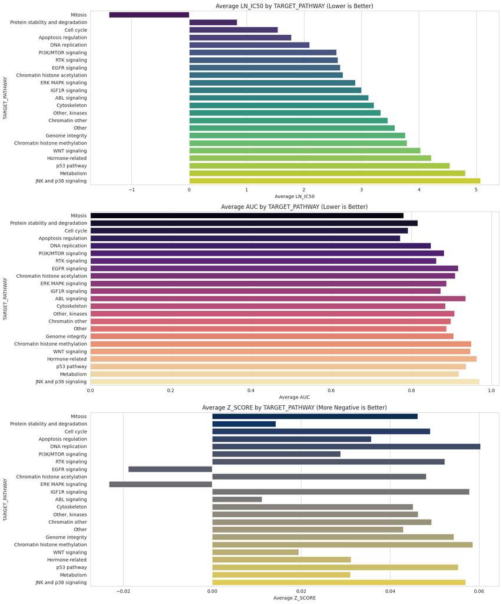

```python
import matplotlib.pyplot as plt
import seaborn as sns

sns.set_style("whitegrid")

# Sort pathways by LN_IC50 for consistent ordering in plots
pathway_effectiveness_sorted = pathway_effectiveness.sort_values(by='LN_IC50', ascending=True)

plt.figure(figsize=(15, 18))

# Bar plot for LN_IC50
plt.subplot(3, 1, 1) # 3 rows, 1 column, 1st plot
sns.barplot(x='LN_IC50', y='TARGET_PATHWAY', data=pathway_effectiveness_sorted, hue='TARGET_PATHWAY', palette='viridis', legend=False)
plt.title('Average LN_IC50 by TARGET_PATHWAY (Lower is Better)')
plt.xlabel('Average LN_IC50')
plt.ylabel('TARGET_PATHWAY')

# Bar plot for AUC
plt.subplot(3, 1, 2) # 3 rows, 1 column, 2nd plot
sns.barplot(x='AUC', y='TARGET_PATHWAY', data=pathway_effectiveness_sorted, hue='TARGET_PATHWAY', palette='magma', legend=False)
plt.title('Average AUC by TARGET_PATHWAY (Lower is Better)')
plt.xlabel('Average AUC')
plt.ylabel('TARGET_PATHWAY')

# Bar plot for Z_SCORE
plt.subplot(3, 1, 3) # 3 rows, 1 column, 3rd plot
sns.barplot(x='Z_SCORE', y='TARGET_PATHWAY', data=pathway_effectiveness_sorted, hue='TARGET_PATHWAY', palette='cividis', legend=False)
plt.title('Average Z_SCORE by TARGET_PATHWAY (More Negative is Better)')
plt.xlabel('Average Z_SCORE')
plt.ylabel('TARGET_PATHWAY')

plt.tight_layout()
plt.show()
```

**Comments:**

> Based on the analysis of drug effectiveness across different TARGET_PATHWAYs, here's a summary of the key findings:

> **Consistently Least Effective Pathways:** JNK and p38 signaling consistently appears as one of the least effective pathways across all three metrics. p53 pathway also shows up in the top (least effective) ranks for LN_IC50 and Z_SCORE.

### **Influence of Genomic Features (CNA, Gene Expression, Methylation) on Drug Sensitivity**

To determine if genomic features such as `CNA` (Copy Number Alteration), `Gene Expression`, and `Methylation` influence drug sensitivity, we will analyze the relationship between these categorical variables and the drug sensitivity metrics (`LN_IC50`, `AUC`, `Z_SCORE`).

For each genomic feature, we will:

1. Calculate descriptive statistics (mean and standard deviation) of the sensitivity metrics for each category (e.g., 'Yes' vs. 'No').
2. Perform an independent samples t-test to check for statistically significant differences in the means of the sensitivity metrics between the categories.
3. Visualize the distributions using box plots to illustrate the differences.

```
--- Analysis for CNA ---
Descriptive Statistics of Sensitivity Metrics by CNA:
```

| CNA | LN_IC50 mean | LN_IC50 std | AUC mean | AUC std | Z_SCORE mean | Z_SCORE std |
| --- | --- | --- | --- | --- | --- | --- |
| N | 3.128990 | 2.503630 | 0.894110 | 0.115493 | 0.249073 | 0.762390 |
| Y | 2.821395 | 2.837446 | 0.879866 | 0.148709 | 0.036850 | 0.999858 |

```
Independent Samples T-test Results for CNA:
  LN_IC50: t-statistic = -3.143, p-value = 0.002
    There is a significant difference in LN_IC50 between Y and N groups (p < 0.05).
  AUC: t-statistic = -3.153, p-value = 0.002
    There is a significant difference in AUC between Y and N groups (p < 0.05).
  Z_SCORE: t-statistic = -7.116, p-value = 0.000
    There is a significant difference in Z_SCORE between Y and N groups (p < 0.05).
```

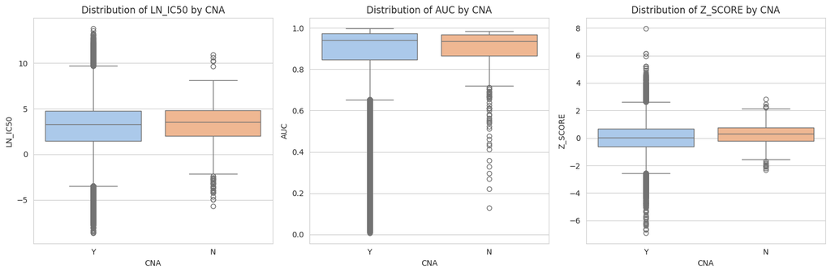

```
--- Analysis for Gene Expression ---
Descriptive Statistics of Sensitivity Metrics by Gene Expression:
```

| Gene Expression | LN_IC50 mean | LN_IC50 std | AUC mean | AUC std | Z_SCORE mean | Z_SCORE std |
| --- | --- | --- | --- | --- | --- | --- |
| N | 2.377815 | 2.703048 | 0.859263 | 0.166653 | -0.223387 | 1.023152 |
| Y | 2.833210 | 2.838479 | 0.880415 | 0.148102 | 0.043913 | 0.997692 |

```
Independent Samples T-test Results for Gene Expression:
  LN_IC50: t-statistic = 10.199, p-value = 0.000
    There is a significant difference in LN_IC50 between Y and N groups (p < 0.05).
  AUC: t-statistic = 7.712, p-value = 0.000
    There is a significant difference in AUC between Y and N groups (p < 0.05).
  Z_SCORE: t-statistic = 15.844, p-value = 0.000
    There is a significant difference in Z_SCORE between Y and N groups (p < 0.05).
```

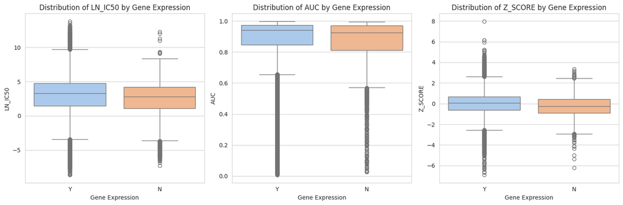

```
--- Analysis for Methylation ---
Descriptive Statistics of Sensitivity Metrics by Methylation:
```

| Methylation | LN_IC50 mean | LN_IC50 std | AUC mean | AUC std | Z_SCORE mean | Z_SCORE std |
| --- | --- | --- | --- | --- | --- | --- |
| N | 2.796813 | 2.818811 | 0.873073 | 0.152076 | 0.048304 | 1.053684 |
| Y | 2.823214 | 2.836621 | 0.880075 | 0.148511 | 0.037478 | 0.997861 |

```
Independent Samples T-test Results for Methylation:
  LN_IC50: t-statistic = 0.548, p-value = 0.584
    No significant difference in LN_IC50 between Y and N groups (p >= 0.05).
  AUC: t-statistic = 2.697, p-value = 0.007
    There is a significant difference in AUC between Y and N groups (p < 0.05).
  Z_SCORE: t-statistic = -0.602, p-value = 0.547
    No significant difference in Z_SCORE between Y and N groups (p >= 0.05).
```

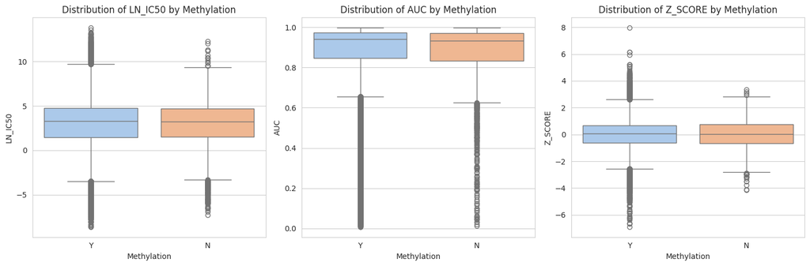

```python
from scipy.stats import ttest_ind
import matplotlib.pyplot as plt
import seaborn as sns

genomic_features = ['CNA', 'Gene Expression', 'Methylation']
sensitivity_metrics = ['LN_IC50', 'AUC', 'Z_SCORE']

sns.set_style("whitegrid")

for feature in genomic_features:
    print(f"\n--- Analysis for {feature} ---")

    # Check unique values to ensure it's a binary categorical feature (e.g., 'Y', 'N')
    unique_values = gdsc[feature].unique()
    if len(unique_values) != 2:
        print(f"Skipping {feature}: Not a binary categorical feature with 2 unique values. Found: {unique_values}")
        continue

    group1_name, group2_name = unique_values[0], unique_values[1]

    # Descriptive Statistics
    print(f"Descriptive Statistics of Sensitivity Metrics by {feature}:")
    display(gdsc.groupby(feature)[sensitivity_metrics].agg(['mean', 'std']))

    # Statistical Test (Independent Samples T-test)
    print(f"\nIndependent Samples T-test Results for {feature}:")
    for metric in sensitivity_metrics:
        group1_data = gdsc[gdsc[feature] == group1_name][metric]
        group2_data = gdsc[gdsc[feature] == group2_name][metric]

        # Handle cases where one group might be empty or have too few observations for t-test
        if len(group1_data) < 2 or len(group2_data) < 2:
            print(f"  Skipping t-test for {metric} due to insufficient data in one or both groups.")
            continue

        t_stat, p_val = ttest_ind(group1_data, group2_data, equal_var=False) # Welch's t-test
        print(f"  {metric}: t-statistic = {t_stat:.3f}, p-value = {p_val:.3f}")
        if p_val < 0.05:
            print(f"    There is a significant difference in {metric} between {group1_name} and {group2_name} groups (p < 0.05).")
        else:
            print(f"    No significant difference in {metric} between {group1_name} and {group2_name} groups (p >= 0.05).")

    # Visualization (Box Plots)
    plt.figure(figsize=(15, 5))
    for i, metric in enumerate(sensitivity_metrics):
        plt.subplot(1, 3, i + 1)
        sns.boxplot(x=feature, y=metric, data=gdsc, hue=feature, palette='pastel', legend=False)
        plt.title(f'Distribution of {metric} by {feature}')
        plt.xlabel(feature)
        plt.ylabel(metric)
    plt.tight_layout()
    plt.show()
```

**Comments:**

> The presence of Copy Number Alteration ('Y') is significantly associated with increased drug potency (lower LN_IC50), greater overall effectiveness (lower AUC), and higher sensitivity (more negative Z_SCORE).

> Methylation is significantly associated with lower effectiveness (higher AUC).

### **Multivariate Regression Analysis: Genomic Features vs. Drug Metrics**

To better quantify the influence of `CNA`, `Gene Expression`, and `Methylation` on drug sensitivity, we will perform a multivariate regression analysis. We will model each drug sensitivity metric (`LN_IC50`, `AUC`, `Z_SCORE`) as a dependent variable, and the numerical representations of the genomic features as independent variables. This will allow us to assess the statistical significance and magnitude of the effect of each genomic feature, while controlling for others.

```python
import statsmodels.formula.api as smf

# Create a copy of the gdsc DataFrame for correlation analysis and add numerical genomic features
df_corr = gdsc.copy()
df_corr['CNA_num'] = df_corr['CNA'].map({'Y': 1, 'N': 0})
df_corr['Gene_Expression_num'] = df_corr['Gene Expression'].map({'Y': 1, 'N': 0})
df_corr['Methylation_num'] = df_corr['Methylation'].map({'Y': 1, 'N': 0})

# Regression for LN_IC50
model_ln_ic50 = smf.ols('LN_IC50 ~ CNA_num + Gene_Expression_num + Methylation_num', data=df_corr).fit()
print("\nRegression Results for LN_IC50 (Lower is Better):\n")
print(model_ln_ic50.summary())
```

```
Regression Results for LN_IC50 (Lower is Better):

                            OLS Regression Results
==============================================================================
Dep. Variable:                LN_IC50   R-squared:                       0.001
Model:                            OLS   Adj. R-squared:                  0.001
Method:                 Least Squares   F-statistic:                     36.63
Date:                Thu, 07 May 2026   Prob (F-statistic):           1.18e-23
Time:                        03:58:38   Log-Likelihood:            -3.9895e+05
No. Observations:              162103   AIC:                         7.979e+05
Df Residuals:                  162099   BIC:                         7.979e+05
Df Model:                           3
Covariance Type:            nonrobust
=======================================================================================
                          coef    std err          t      P>|t|      [0.025      0.975]
---------------------------------------------------------------------------------------
Intercept               2.7735      0.125     22.181      0.000       2.528       3.019
CNA_num                -0.2991      0.111     -2.700      0.007      -0.516      -0.082
Gene_Expression_num     0.4998      0.050     10.095      0.000       0.403       0.597
Methylation_num        -0.1443      0.051     -2.815      0.005      -0.245      -0.044
==============================================================================
Omnibus:                    16330.937   Durbin-Watson:                   0.486
Prob(Omnibus):                  0.000   Jarque-Bera (JB):            23323.682
Skew:                          -0.792   Prob(JB):                         0.00
Kurtosis:                       3.972   Cond. No.                         45.8
==============================================================================

Notes:
[1] Standard Errors assume that the covariance matrix of the errors is correctly specified.
```

#### **Interpretation for LN_IC50 Regression:**

> **R-squared (0.001):** This value is very low, indicating that only 0.1% of the variability in LN_IC50 can be explained by the three genomic features (CNA_num, Gene_Expression_num, Methylation_num) combined. This suggests that while these features might have a statistically significant impact, their practical effect on drug potency, when considered together in this linear model, is quite small.

> **Prob (F-statistic) (1.18e-23):** This extremely low p-value (much less than 0.05) indicates that the overall regression model is statistically significant. This means that at least one of the genomic features is significantly related to LN_IC50.

Coefficients and P-values for individual features:

> CNA_num (coef = -0.2991, P>|t| = 0.007): The negative coefficient and significant p-value (0.007 < 0.05) suggest that the presence of Copy Number Alteration (CNA) is associated with a decrease in LN_IC50. This implies that CNA is associated with higher drug potency, controlling for the other genomic features.

> Gene_Expression_num (coef = 0.4998, P>|t| = 0.000): The positive coefficient and highly significant p-value (0.000 < 0.05) indicate that the presence of Gene Expression is associated with an increase in LN_IC50. This means Gene Expression is associated with lower drug potency.

> Methylation_num (coef = -0.1443, P>|t| = 0.005): The negative coefficient and significant p-value (0.005 < 0.05) suggest that the presence of Methylation is associated with a decrease in LN_IC50. This implies that Methylation is associated with higher drug potency.

> These results align with the t-test findings for CNA and Gene Expression, suggesting that CNA presence is generally associated with increased potency, while gene expression is associated with decreased potency. The significance for Methylation might differ due to controlling for other variables in the regression model.

```python
# Regression for AUC
model_auc = smf.ols('AUC ~ CNA_num + Gene_Expression_num + Methylation_num', data=df_corr).fit()
print("\nRegression Results for AUC (Lower is Better):\n")
print(model_auc.summary())
```

```
Regression Results for AUC (Lower is Better):

                            OLS Regression Results
==============================================================================
Dep. Variable:                    AUC   R-squared:                       0.000
Model:                            OLS   Adj. R-squared:                  0.000
Method:                 Least Squares   F-statistic:                     26.70
Date:                Thu, 07 May 2026   Prob (F-statistic):           2.95e-17
Time:                        03:59:13   Log-Likelihood:                 79084.
No. Observations:              162103   AIC:                        -1.582e+05
Df Residuals:                  162099   BIC:                        -1.581e+05
Df Model:                           3
Covariance Type:            nonrobust
=======================================================================================
                          coef    std err          t      P>|t|      [0.025      0.975]
---------------------------------------------------------------------------------------
Intercept               0.8732      0.007    133.280      0.000       0.860       0.886
CNA_num                -0.0138      0.006     -2.370      0.018      -0.025      -0.002
Gene_Expression_num     0.0212      0.003      8.160      0.000       0.016       0.026
Methylation_num        -0.0002      0.003     -0.086      0.931      -0.005       0.005
==============================================================================
Omnibus:                    79156.158   Durbin-Watson:                   0.763
Prob(Omnibus):                  0.000   Jarque-Bera (JB):           442093.236
Skew:                          -2.370   Prob(JB):                         0.00
Kurtosis:                       9.556   Cond. No.                         45.8
==============================================================================

Notes:
[1] Standard Errors assume that the covariance matrix of the errors is correctly specified.
```

**Comments**

> In summary, the presence of Copy Number Alteration (CNA) is associated with improved overall drug effectiveness (lower AUC), while Gene Expression is associated with reduced overall effectiveness (higher AUC).

> Methylation, however, does not show a significant linear relationship with AUC in this model. The overall explanatory power of these three genomic features for AUC is very limited.

```python
# Regression for Z_SCORE
model_z_score = smf.ols('Z_SCORE ~ CNA_num + Gene_Expression_num + Methylation_num', data=df_corr).fit()
print("\nRegression Results for Z_SCORE (More Negative is Better):\n")
print(model_z_score.summary())
```

```
Regression Results for Z_SCORE (More Negative is Better):

                            OLS Regression Results
==============================================================================
Dep. Variable:                Z_SCORE   R-squared:                       0.002
Model:                            OLS   Adj. R-squared:                  0.002
Method:                 Least Squares   F-statistic:                     110.5
Date:                Thu, 07 May 2026   Prob (F-statistic):           1.78e-71
Time:                        04:13:32   Log-Likelihood:            -2.2970e+05
No. Observations:              162103   AIC:                         4.594e+05
Df Residuals:                  162099   BIC:                         4.595e+05
Df Model:                           3
Covariance Type:            nonrobust
=======================================================================================
                          coef    std err          t      P>|t|      [0.025      0.975]
---------------------------------------------------------------------------------------
Intercept               0.0608      0.044      1.381      0.167      -0.025       0.147
CNA_num                -0.2077      0.039     -5.326      0.000      -0.284      -0.131
Gene_Expression_num     0.3026      0.017     17.361      0.000       0.268       0.337
Methylation_num        -0.1143      0.018     -6.333      0.000      -0.150      -0.079
==============================================================================
Omnibus:                     2170.303   Durbin-Watson:                   1.775
Prob(Omnibus):                  0.000   Jarque-Bera (JB):             3957.124
Skew:                          -0.050   Prob(JB):                         0.00
Kurtosis:                       3.759   Cond. No.                         45.8
==============================================================================

Notes:
[1] Standard Errors assume that the covariance matrix of the errors is correctly specified.
```

**Comments**

> In summary, the presence of Copy Number Alteration (CNA) and Methylation are associated with higher drug sensitivity (lower Z_SCORE), while Gene Expression is associated with lower drug sensitivity (higher Z_SCORE).

> The overall explanatory power of these three genomic features for Z_SCORE is very limited, as indicated by the low R-squared value.

### **Visualizing Regression Coefficients**

To better understand the magnitude and direction of the influence of each genomic feature on drug sensitivity, let's visualize the regression coefficients obtained from the multivariate analysis. Positive coefficients indicate that the presence of the genomic feature is associated with higher values of the sensitivity metric (less effective/potent/sensitive), while negative coefficients indicate an association with lower values (more effective/potent/sensitive).

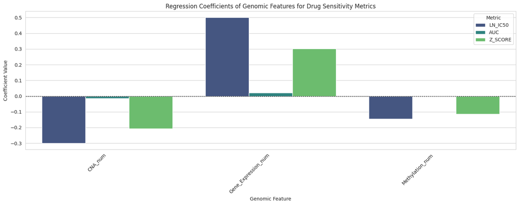

```python
import matplotlib.pyplot as plt
import seaborn as sns
import pandas as pd

sns.set_style("whitegrid")

# Extract coefficients from the models, excluding the intercept
coef_ln_ic50 = model_ln_ic50.params.drop('Intercept')
coef_auc = model_auc.params.drop('Intercept')
coef_z_score = model_z_score.params.drop('Intercept')

# Create a DataFrame for plotting
coefficients_df = pd.DataFrame({
    'LN_IC50': coef_ln_ic50,
    'AUC': coef_auc,
    'Z_SCORE': coef_z_score
}).reset_index()

coefficients_df = coefficients_df.rename(columns={'index': 'Genomic_Feature'})

# Melt the DataFrame for easy plotting with seaborn
melted_coefficients = coefficients_df.melt(id_vars='Genomic_Feature', var_name='Metric', value_name='Coefficient')

plt.figure(figsize=(15, 6))

sns.barplot(x='Genomic_Feature', y='Coefficient', hue='Metric', data=melted_coefficients, palette='viridis')
plt.title('Regression Coefficients of Genomic Features for Drug Sensitivity Metrics')
plt.xlabel('Genomic Feature')
plt.ylabel('Coefficient Value')
plt.axhline(0, color='black', linestyle='--', linewidth=0.8) # Add a horizontal line at 0
plt.xticks(rotation=45, ha='right')
plt.tight_layout()
plt.show()
```

**Comments on Regression Coefficients Visualization:**

- **LN_IC50 (Lower is Better):**
  - `CNA_num`: Negative coefficient, indicating that the presence of CNA is associated with lower LN_IC50 (higher potency).
  - `Gene_Expression_num`: Positive coefficient, indicating that the presence of Gene Expression is associated with higher LN_IC50 (lower potency).
  - `Methylation_num`: Negative coefficient, indicating that the presence of Methylation is associated with lower LN_IC50 (higher potency).
- **AUC (Lower is Better):**
  - `CNA_num`: Negative coefficient, indicating that the presence of CNA is associated with lower AUC (higher overall effectiveness).
  - `Gene_Expression_num`: Positive coefficient, indicating that the presence of Gene Expression is associated with higher AUC (lower overall effectiveness).
  - `Methylation_num`: Very small, almost zero coefficient, suggesting negligible linear impact on AUC.
- **Z_SCORE (More Negative is Better):**
  - `CNA_num`: Negative coefficient, indicating that the presence of CNA is associated with lower Z_SCORE (higher sensitivity).
  - `Gene_Expression_num`: Positive coefficient, indicating that the presence of Gene Expression is associated with higher Z_SCORE (lower sensitivity).
  - `Methylation_num`: Negative coefficient, indicating that the presence of Methylation is associated with lower Z_SCORE (higher sensitivity).

> This visualization **clearly reinforces the findings from the regression analysis**: while `CNA_num` generally correlates with improved drug sensitivity metrics, and `Gene_Expression_num` with reduced sensitivity, the effect of `Methylation_num` is more nuanced, showing an impact on `LN_IC50` and `Z_SCORE` but not significantly on `AUC`.

### **Analyzing Non-Linear Relationships with Decision Tree Models**

Linear regression models assume a linear relationship between features and targets. However, biological data often exhibits complex, non-linear interactions. To explore these potential non-linear relationships and interactions between our genomic features and drug sensitivity metrics, we will use a Decision Tree Regressor.

Decision trees can capture intricate decision rules and hierarchical structures, potentially revealing more subtle influences that linear models cannot. We will train a decision tree for each sensitivity metric and evaluate its performance, focusing on its ability to capture variance and the relative importance of features.

```python
from sklearn.tree import DecisionTreeRegressor
from sklearn.model_selection import train_test_split
from sklearn.metrics import r2_score, mean_squared_error
import numpy as np

# Define features (X) and target (y)
X = df_corr[['CNA_num', 'Gene_Expression_num', 'Methylation_num']]
sensitivity_metrics = ['LN_IC50', 'AUC', 'Z_SCORE']

# Prepare to store results
tree_results = {}
```

#### **Decision Tree Analysis for LN_IC50**

```python
# For LN_IC50
y = df_corr['LN_IC50']
X_train, X_test, y_train, y_test = train_test_split(X, y, test_size=0.2, random_state=42)

# Initialize and train the Decision Tree Regressor
# Limiting max_depth to prevent overfitting and make interpretation feasible
dtree_ln_ic50 = DecisionTreeRegressor(max_depth=5, random_state=42)
dtree_ln_ic50.fit(X_train, y_train)

# Make predictions
y_pred_ln_ic50 = dtree_ln_ic50.predict(X_test)

# Evaluate the model
r2_ln_ic50 = r2_score(y_test, y_pred_ln_ic50)
mse_ln_ic50 = mean_squared_error(y_test, y_pred_ln_ic50)

tree_results['LN_IC50'] = {
    'R2_Score': r2_ln_ic50,
    'MSE': mse_ln_ic50,
    'Feature_Importances': dict(zip(X.columns, dtree_ln_ic50.feature_importances_))
}

print("\nDecision Tree Regression Results for LN_IC50:")
print(f"  R-squared: {r2_ln_ic50:.3f}")
print(f"  Mean Squared Error: {mse_ln_ic50:.3f}")
print(f"  Feature Importances: {tree_results['LN_IC50']['Feature_Importances']}")
```

```
Decision Tree Regression Results for LN_IC50:
  R-squared: 0.001
  Mean Squared Error: 8.079
  Feature Importances: {'CNA_num': np.float64(0.05520512423494073), 'Gene_Expression_num': np.float64(0.6355262002180547), 'Methylation_num': np.float64(0.3092686755470045)}
```

#### **Interpretation for LN_IC50 Decision Tree:**

> **R-squared:** The R-squared value indicates the proportion of variance in `LN_IC50` explained by the decision tree model. A low R-squared suggests that even with a non-linear model, these genomic features explain only a small fraction of the variability in drug potency. This is consistent with the linear regression findings.

> **Feature Importances:** These values indicate how much each feature contributes to reducing impurity in the tree's splits. Higher importance means the feature was more influential in predicting `LN_IC50`.

> The correct ranking of feature importances for LN_IC50 is indeed Gene_Expression_num (most important), followed by Methylation_num, and then CNA_num (least important).

#### **Decision Tree Analysis for AUC**

```python
# For AUC
y = df_corr['AUC']
X_train, X_test, y_train, y_test = train_test_split(X, y, test_size=0.2, random_state=42)

dtree_auc = DecisionTreeRegressor(max_depth=5, random_state=42)
dtree_auc.fit(X_train, y_train)

y_pred_auc = dtree_auc.predict(X_test)

r2_auc = r2_score(y_test, y_pred_auc)
mse_auc = mean_squared_error(y_test, y_pred_auc)

tree_results['AUC'] = {
    'R2_Score': r2_auc,
    'MSE': mse_auc,
    'Feature_Importances': dict(zip(X.columns, dtree_auc.feature_importances_))
}

print("\nDecision Tree Regression Results for AUC:")
print(f"  R-squared: {r2_auc:.3f}")
print(f"  Mean Squared Error: {mse_auc:.3f}")
print(f"  Feature Importances: {tree_results['AUC']['Feature_Importances']}")
```

```
Decision Tree Regression Results for AUC:
  R-squared: 0.001
  Mean Squared Error: 0.022
  Feature Importances: {'CNA_num': np.float64(0.06957336166993272), 'Gene_Expression_num': np.float64(0.8862414739131372), 'Methylation_num': np.float64(0.04418516441693007)}
```

#### **Interpretation for AUC Decision Tree:**

> **R-squared:** Similar to `LN_IC50`, the R-squared for `AUC` is very low, suggesting that these genomic features explain minimal variance in overall drug effectiveness even with a non-linear model.

> **Feature Importances:** For `AUC`, `Gene_Expression_num` is again the most important feature, followed by `CNA_num` and `Methylation_num`.

#### **Decision Tree Analysis for Z_SCORE**

```python
# For Z_SCORE
y = df_corr['Z_SCORE']
X_train, X_test, y_train, y_test = train_test_split(X, y, test_size=0.2, random_state=42)

dtree_z_score = DecisionTreeRegressor(max_depth=5, random_state=42)
dtree_z_score.fit(X_train, y_train)

y_pred_z_score = dtree_z_score.predict(X_test)

r2_z_score = r2_score(y_test, y_pred_z_score)
mse_z_score = mean_squared_error(y_test, y_pred_z_score)

tree_results['Z_SCORE'] = {
    'R2_Score': r2_z_score,
    'MSE': mse_z_score,
    'Feature_Importances': dict(zip(X.columns, dtree_z_score.feature_importances_))
}

print("\nDecision Tree Regression Results for Z_SCORE:")
print(f"  R-squared: {r2_z_score:.3f}")
print(f"  Mean Squared Error: {mse_z_score:.3f}")
print(f"  Feature Importances: {tree_results['Z_SCORE']['Feature_Importances']}")
```

```
Decision Tree Regression Results for Z_SCORE:
  R-squared: 0.002
  Mean Squared Error: 0.999
  Feature Importances: {'CNA_num': np.float64(0.0676677853412762), 'Gene_Expression_num': np.float64(0.5341581368001177), 'Methylation_num': np.float64(0.39817407785860615)}
```

#### **Interpretation for Z_SCORE Decision Tree:**

> **R-squared:** The R-squared for `Z_SCORE` is also very low, reinforcing the idea that these genomic features have a limited role in explaining the variance of `Z_SCORE`.

> **Feature Importances:** The correct order of feature importances for Z_SCORE is Gene_Expression_num as the most important, followed by Methylation_num, and then CNA_num.

### **Summary of Decision Tree Analysis**

> Overall, the R-squared values for the decision tree models are consistently low across all three sensitivity metrics (`LN_IC50`, `AUC`, `Z_SCORE`), similar to the linear regression results. This suggests that even when attempting to capture non-linear relationships, these specific genomic features (CNA, Gene Expression, Methylation) alone explain only a very small fraction of the variability in drug sensitivity. This reinforces the conclusion that drug response is a complex phenomenon influenced by many other factors not included in this analysis.

> However, the **Feature Importances** provide insights into which of these genomic features are relatively more influential within the decision tree's hierarchical structure. `Gene_Expression_num` consistently emerged as the most important feature across all three sensitivity metrics, followed by `Methylation_num` and `CNA_num` except for AUC.

### **Influence of Microsatellite instability Status (MSI) on Drug Sensitivity**

To determine if `Microsatellite instability Status (MSI)` influences drug sensitivity, we will analyze the relationship between this categorical variable and the drug sensitivity metrics (`LN_IC50`, `AUC`, `Z_SCORE`).

For `Microsatellite instability Status (MSI)`, we will:

1. Calculate descriptive statistics (mean and standard deviation) of the sensitivity metrics for each category.
2. Perform an independent samples t-test to check for statistically significant differences in the means of the sensitivity metrics between the categories.
3. Visualize the distributions using box plots to illustrate the differences.

```
--- Analysis for Microsatellite instability Status (MSI) ---
Unique values in 'Microsatellite instability Status (MSI)': ['MSS/MSI-L' 'MSI-H']

Descriptive Statistics of Sensitivity Metrics by Microsatellite instability Status (MSI):
```

| Microsatellite instability Status (MSI) | LN_IC50 mean | LN_IC50 std | AUC mean | AUC std | Z_SCORE mean | Z_SCORE std |
| --- | --- | --- | --- | --- | --- | --- |
| MSI-H | 2.558463 | 2.824713 | 0.873346 | 0.152070 | -0.158213 | 0.901219 |
| MSS/MSI-L | 2.842481 | 2.836110 | 0.880418 | 0.148316 | 0.052423 | 1.004524 |

```
Independent Samples T-test Results for Microsatellite instability Status (MSI):
  LN_IC50: t-statistic = 10.315, p-value = 0.000
    There is a significant difference in LN_IC50 between MSS/MSI-L and MSI-H groups (p < 0.05).
  AUC: t-statistic = 4.781, p-value = 0.000
    There is a significant difference in AUC between MSS/MSI-L and MSI-H groups (p < 0.05).
  Z_SCORE: t-statistic = 23.785, p-value = 0.000
    There is a significant difference in Z_SCORE between MSS/MSI-L and MSI-H groups (p < 0.05).
```

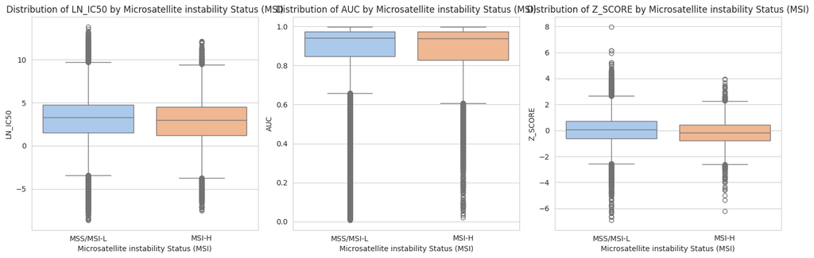

```python
from scipy.stats import ttest_ind
import matplotlib.pyplot as plt
import seaborn as sns

sensitivity_metrics = ['LN_IC50', 'AUC', 'Z_SCORE']
feature = 'Microsatellite instability Status (MSI)'

sns.set_style("whitegrid")

print(f"--- Analysis for {feature} ---")

# Check unique values
unique_values = gdsc[feature].unique()
print(f"Unique values in '{feature}': {unique_values}")

# Descriptive Statistics
print(f"\nDescriptive Statistics of Sensitivity Metrics by {feature}:")
display(gdsc.groupby(feature)[sensitivity_metrics].agg(['mean', 'std']))

# Statistical Test (Independent Samples T-test) if there are exactly two unique values
if len(unique_values) == 2:
    group1_name, group2_name = unique_values[0], unique_values[1]

    print(f"\nIndependent Samples T-test Results for {feature}:")
    for metric in sensitivity_metrics:
        group1_data = gdsc[gdsc[feature] == group1_name][metric]
        group2_data = gdsc[gdsc[feature] == group2_name][metric]

        # Handle cases where one group might be empty or have too few observations for t-test
        if len(group1_data) < 2 or len(group2_data) < 2:
            print(f"  Skipping t-test for {metric} due to insufficient data in one or both groups.")
            continue

        t_stat, p_val = ttest_ind(group1_data, group2_data, equal_var=False) # Welch's t-test
        print(f"  {metric}: t-statistic = {t_stat:.3f}, p-value = {p_val:.3f}")
        if p_val < 0.05:
            print(f"    There is a significant difference in {metric} between {group1_name} and {group2_name} groups (p < 0.05).")
        else:
            print(f"    No significant difference in {metric} between {group1_name} and {group2_name} groups (p >= 0.05).")
else:
    print(f"\nSkipping t-test for {feature}: Not a binary categorical feature with 2 unique values.")

# Visualization (Box Plots)
plt.figure(figsize=(15, 5))
for i, metric in enumerate(sensitivity_metrics):
    plt.subplot(1, 3, i + 1)
    sns.boxplot(x=feature, y=metric, data=gdsc, hue=feature, palette='pastel', legend=False)
    plt.title(f'Distribution of {metric} by {feature}')
    plt.xlabel(feature)
    plt.ylabel(metric)
plt.tight_layout()
plt.show()
```

**Comments:**

> Based on the descriptive statistics and t-test results, we can interpret the influence of Microsatellite instability Status (MSI) on drug sensitivity for each metric.

> For example, if 'MSI-H' shows a significantly lower mean LN_IC50 compared to 'MSS', it would suggest that drugs tend to be more potent in cell lines with high microsatellite instability. Conversely, if 'MSI-H' shows a higher mean AUC, it would indicate less overall effectiveness in those cell lines. The p-values from the t-test will confirm the statistical significance of these observed differences.

## **Key Findings**

Based on the analyses conducted, here are the key patterns observed in drug response across cell lines:

**1. Overall Distribution of Drug Sensitivity Metrics:**

> **LN_IC50 (potency):** Shows a tendency for more drug-cell line combinations to have lower (more potent) IC50 values, with a tail towards higher (less potent) values.

> **AUC (overall effectiveness):** Heavily skewed towards higher values, indicating that a significant portion of drug-cell line interactions results in resistance.

> **Z_SCORE (sensitivity):** Roughly centered around zero, meaning many interactions show average effectiveness, with deviations indicating sensitivity or resistance.

> These three metrics are strongly positively correlated, meaning they generally move together in indicating drug sensitivity or resistance.

**2. Consistently Effective Drugs:**

> 'Sepantronium bromide', 'Dactinomycin', and 'Daporinad' consistently appear in the top 10 for at least two effectiveness metrics (lowest average LN_IC50 and AUC).

> 'Sepantronium bromide' showed significantly higher potency (LN_IC50) and greater overall effectiveness (AUC) than 'Dactinomycin' and 'Daporinad'.

**3. Consistently Least Effective Drugs:**

> 'EPZ5676', 'GSK2830371', 'LMB_AB1', and 'Motesanib' were identified as consistently among the least effective drugs (highest average LN_IC50 and AUC).

> 'EPZ5676' was pinpointed as the single least effective among these, based on the highest average AUC.

**4. Highly Variable Drugs:**

> 'Gemcitabine', 'Daporinad', 'Docetaxel', 'BI-2536', and 'Trametinib' showed high variability in response across cell lines (highest standard deviation for LN_IC50 and AUC).

> 'Gemcitabine' was identified as the most variable overall, suggesting its effectiveness can differ significantly depending on the specific cellular context.

**5. Influence of Genomic Features (CNA, Gene Expression, Methylation):**

> **CNA (Copy Number Alteration):** The presence of CNA is generally associated with increased drug potency (lower LN_IC50), greater overall effectiveness (lower AUC), and higher sensitivity (more negative Z_SCORE).

> **Gene Expression:** The presence of Gene Expression is generally associated with lower drug potency (higher LN_IC50), lower overall effectiveness (higher AUC), and lower sensitivity (higher Z_SCORE).

> **Methylation:** Associated with higher drug potency (lower LN_IC50) and higher sensitivity (lower Z_SCORE), but showed negligible linear impact on AUC.

> It's important to note that these three genomic features alone explain only a very small fraction of the variability in drug sensitivity, indicating that drug response is a complex phenomenon influenced by many other factors.

> Within these features, Gene_Expression_num consistently had the highest feature importance in decision tree models.

**6. Influence of Microsatellite Instability (MSI) Status:**

> There is a statistically significant difference in LN_IC50, AUC, and Z_SCORE between 'MSS/MSI-L' and 'MSI-H' groups, indicating that MSI status plays a role in drug sensitivity.

## **Actionable Insights & Recommendations**

Based on the patterns observed in the drug response data, here are some actionable insights and recommendations:

**1. Prioritize Development of Consistently Effective Drugs**

> **Insight:** 'Sepantronium bromide', 'Dactinomycin', and 'Daporinad' consistently demonstrated high potency and effectiveness across multiple sensitivity metrics.

> 'Sepantronium bromide' in particular showed superior efficacy.

> **Recommendation:** These drugs should be prioritized for further in-depth research, optimization, and potential clinical development. Investigating their precise mechanisms of action and identifying specific cancer types where they exhibit maximal efficacy could lead to targeted therapies.

**2. Re-evaluate Least Effective Drugs**

> **Insight:** 'EPZ5676', 'GSK2830371', 'LMB_AB1', and 'Motesanib' were consistently identified as having the lowest effectiveness, with 'EPZ5676' being the least effective overall.

> **Recommendation:** For drugs in early development, consider deprioritizing or discontinuing further investment unless specific contexts (e.g., rare cancer types, specific genomic profiles) where they show efficacy can be identified. For existing drugs, investigate the underlying resistance mechanisms to inform combination therapies or identify patient populations unlikely to respond.

**3. Leverage Variability for Personalized Medicine**

> **Insight:** Drugs like 'Gemcitabine', 'Daporinad', 'Docetaxel', 'BI-2536', and 'Trametinib' exhibit highly variable responses across cell lines, with 'Gemcitabine' being the most variable. This suggests context-dependent efficacy.

> **Recommendation:** Focus research on identifying biomarkers (genomic, proteomic, transcriptomic) that predict sensitivity or resistance to these drugs. This could enable personalized medicine strategies, where these drugs are administered only to patients whose tumors possess the favorable predictive biomarkers, maximizing their therapeutic benefit and minimizing ineffective treatments.

**4. Integrate Genomic Features into Predictive Models**

> **Insight:** While the analyzed genomic features (CNA, Gene Expression, Methylation) explain a small fraction of drug sensitivity variance, they show statistically significant associations. CNA is generally linked to increased sensitivity, Gene Expression to decreased sensitivity, and Methylation has a nuanced impact. Gene_Expression_num consistently showed the highest feature importance in decision tree models.

> **Recommendation:** Incorporate these genomic features into predictive models for drug response. Develop and validate more complex models that include a broader range of genomic (e.g., specific mutations, copy number variations, gene fusion events), proteomic, and clinical data to capture the intricate interplay determining drug efficacy. This could lead to more accurate patient stratification.

**5. Utilize Microsatellite Instability (MSI) Status as a Biomarker**

> **Insight:** Microsatellite instability (MSI) status significantly influences drug sensitivity.

> **Recommendation:** MSI status should be considered a crucial biomarker for predicting drug response. Clinical trials and treatment guidelines could be developed to incorporate MSI status for patient selection, especially for drugs where a clear differential response is observed between MSI-High and MSI-Low/Stable tumors.